# Xử lý số liệu thống kê - FIFA Data

Nhóm 8

2025-1-10

# Thông tin nhóm

1. Kha Thái Hồ - 22280025 - Leader
2. Nguyễn Văn Trung Chính - 22280007 - Member
3. Trần Chí Hữu - 22280038 - Member
4. Huỳnh Ngọc Hòa - 22280026 - Member
5. Lê Phan Ngọc Hiếu - 22280023 - Member

# I.Cài đặt thư viện và tải dữ liệu

```r
# Đọc dữ liệu
fifa_data <- read_csv('Dataset/fifa_eda_stats.csv')
```

# II.Tiền xử lý dữ liệu

## 1.Làm sạch tên biến

Dùng lệnh clean_names() để đưa tên biến về định dạng phù hợp

```r
cleaned_data <- fifa_data |> clean_names()
```

## 2.Tổng quan dữ liệu

Xem xét tổng quan dữ liệu bằng lệnh skim

```r
skim(cleaned_data)
```

Data summary

| Name | cleaned_data |
| --- | --- |
| Number of rows | 18207 |
| Number of columns | 57 |
| _______________________ |  |
| Column type frequency: |  |
| character | 15 |
| numeric | 42 |
| ________________________ |  |
| Group variables | None |

**Variable type: character**

| skim_variable | n_missing | complete_rate | min | max | empty | n_unique | whitespace |
| --- | --- | --- | --- | --- | --- | --- | --- |
| name | 0 | 1.00 | 2 | 22 | 0 | 17194 | 0 |
| nationality | 0 | 1.00 | 4 | 20 | 0 | 164 | 0 |
| club | 241 | 0.99 | 3 | 35 | 0 | 651 | 0 |
| value | 0 | 1.00 | 2 | 7 | 0 | 217 | 0 |
| wage | 0 | 1.00 | 2 | 5 | 0 | 144 | 0 |
| preferred_foot | 48 | 1.00 | 4 | 5 | 0 | 2 | 0 |
| work_rate | 48 | 1.00 | 8 | 14 | 0 | 9 | 0 |
| body_type | 48 | 1.00 | 4 | 19 | 0 | 10 | 0 |
| position | 60 | 1.00 | 2 | 3 | 0 | 27 | 0 |
| joined | 1553 | 0.91 | 11 | 12 | 0 | 1736 | 0 |
| loaned_from | 16943 | 0.07 | 3 | 35 | 0 | 341 | 0 |
| contract_valid_until | 289 | 0.98 | 4 | 12 | 0 | 36 | 0 |
| height | 48 | 1.00 | 3 | 4 | 0 | 21 | 0 |
| weight | 48 | 1.00 | 6 | 6 | 0 | 57 | 0 |
| release_clause | 1564 | 0.91 | 3 | 7 | 0 | 1244 | 0 |

**Variable type: numeric**

| skim_variable | n_missing | complete_rate | mean | sd | p0 | p25 | p50 | p75 | p100 | hist |
| --- | --- | --- | --- | --- | --- | --- | --- | --- | --- | --- |
| id | 0 | 1 | 214298.34 | 29965.24 | 16 | 200315.5 | 221759 | 236529.5 | 246620 | ▁▁▁▂▇ |
| age | 0 | 1 | 25.12 | 4.67 | 16 | 21.0 | 25 | 28.0 | 45 | ▅▇▅▁▁ |
| overall | 0 | 1 | 66.24 | 6.91 | 46 | 62.0 | 66 | 71.0 | 94 | ▁▇▇▂▁ |
| potential | 0 | 1 | 71.31 | 6.14 | 48 | 67.0 | 71 | 75.0 | 95 | ▁▃▇▂▁ |
| international_reputation | 48 | 1 | 1.11 | 0.39 | 1 | 1.0 | 1 | 1.0 | 5 | ▇▁▁▁▁ |
| weak_foot | 48 | 1 | 2.95 | 0.66 | 1 | 3.0 | 3 | 3.0 | 5 | ▁▂▇▂▁ |
| skill_moves | 48 | 1 | 2.36 | 0.76 | 1 | 2.0 | 2 | 3.0 | 5 | ▂▇▆▁▁ |
| jersey_number | 60 | 1 | 19.55 | 15.95 | 1 | 8.0 | 17 | 26.0 | 99 | ▇▅▁▁▁ |
| crossing | 48 | 1 | 49.73 | 18.36 | 5 | 38.0 | 54 | 64.0 | 93 | ▂▃▆▇▁ |
| finishing | 48 | 1 | 45.55 | 19.53 | 2 | 30.0 | 49 | 62.0 | 95 | ▃▆▇▇▁ |
| heading_accuracy | 48 | 1 | 52.30 | 17.38 | 4 | 44.0 | 56 | 64.0 | 94 | ▂▂▇▇▁ |
| short_passing | 48 | 1 | 58.69 | 14.70 | 7 | 54.0 | 62 | 68.0 | 93 | ▁▁▃▇▁ |
| volleys | 48 | 1 | 42.91 | 17.69 | 4 | 30.0 | 44 | 57.0 | 90 | ▃▆▇▆▁ |
| dribbling | 48 | 1 | 55.37 | 18.91 | 4 | 49.0 | 61 | 68.0 | 97 | ▂▁▅▇▁ |
| curve | 48 | 1 | 47.17 | 18.40 | 6 | 34.0 | 48 | 62.0 | 94 | ▃▆▇▇▁ |
| fk_accuracy | 48 | 1 | 42.86 | 17.48 | 3 | 31.0 | 41 | 57.0 | 94 | ▃▇▇▅▁ |
| long_passing | 48 | 1 | 52.71 | 15.33 | 9 | 43.0 | 56 | 64.0 | 93 | ▂▃▇▇▁ |
| ball_control | 48 | 1 | 58.37 | 16.69 | 5 | 54.0 | 63 | 69.0 | 96 | ▁▁▃▇▁ |
| acceleration | 48 | 1 | 64.61 | 14.93 | 12 | 57.0 | 67 | 75.0 | 97 | ▁▂▃▇▂ |
| sprint_speed | 48 | 1 | 64.73 | 14.65 | 12 | 57.0 | 67 | 75.0 | 96 | ▁▂▃▇▂ |
| agility | 48 | 1 | 63.50 | 14.77 | 14 | 55.0 | 66 | 74.0 | 96 | ▁▂▅▇▂ |
| reactions | 48 | 1 | 61.84 | 9.01 | 21 | 56.0 | 62 | 68.0 | 96 | ▁▂▇▅▁ |
| balance | 48 | 1 | 63.97 | 14.14 | 16 | 56.0 | 66 | 74.0 | 96 | ▁▂▆▇▂ |
| shot_power | 48 | 1 | 55.46 | 17.24 | 2 | 45.0 | 59 | 68.0 | 95 | ▁▂▅▇▁ |
| jumping | 48 | 1 | 65.09 | 11.82 | 15 | 58.0 | 66 | 73.0 | 95 | ▁▁▆▇▂ |
| stamina | 48 | 1 | 63.22 | 15.89 | 12 | 56.0 | 66 | 74.0 | 96 | ▁▂▃▇▂ |
| strength | 48 | 1 | 65.31 | 12.56 | 17 | 58.0 | 67 | 74.0 | 97 | ▁▂▆▇▂ |
| long_shots | 48 | 1 | 47.11 | 19.26 | 3 | 33.0 | 51 | 62.0 | 94 | ▃▅▇▇▁ |
| aggression | 48 | 1 | 55.87 | 17.37 | 11 | 44.0 | 59 | 69.0 | 95 | ▂▃▇▇▂ |
| interceptions | 48 | 1 | 46.70 | 20.70 | 3 | 26.0 | 52 | 64.0 | 92 | ▃▅▅▇▁ |
| positioning | 48 | 1 | 49.96 | 19.53 | 2 | 38.0 | 55 | 64.0 | 95 | ▂▃▆▇▁ |
| vision | 48 | 1 | 53.40 | 14.15 | 10 | 44.0 | 55 | 64.0 | 94 | ▁▅▇▆▁ |
| penalties | 48 | 1 | 48.55 | 15.70 | 5 | 39.0 | 49 | 60.0 | 92 | ▂▃▇▆▁ |
| composure | 48 | 1 | 58.65 | 11.44 | 3 | 51.0 | 60 | 67.0 | 96 | ▁▁▆▇▁ |
| marking | 48 | 1 | 47.28 | 19.90 | 3 | 30.0 | 53 | 64.0 | 94 | ▃▅▅▇▁ |
| standing_tackle | 48 | 1 | 47.70 | 21.66 | 2 | 27.0 | 55 | 66.0 | 93 | ▃▃▃▇▁ |
| sliding_tackle | 48 | 1 | 45.66 | 21.29 | 3 | 24.0 | 52 | 64.0 | 91 | ▅▃▃▇▁ |
| gk_diving | 48 | 1 | 16.62 | 17.70 | 1 | 8.0 | 11 | 14.0 | 90 | ▇▁▁▁▁ |
| gk_handling | 48 | 1 | 16.39 | 16.91 | 1 | 8.0 | 11 | 14.0 | 92 | ▇▁▁▁▁ |
| gk_kicking | 48 | 1 | 16.23 | 16.50 | 1 | 8.0 | 11 | 14.0 | 91 | ▇▁▁▁▁ |
| gk_positioning | 48 | 1 | 16.39 | 17.03 | 1 | 8.0 | 11 | 14.0 | 90 | ▇▁▁▁▁ |
| gk_reflexes | 48 | 1 | 16.71 | 17.96 | 1 | 8.0 | 11 | 14.0 | 94 | ▇▁▁▁▁ |

**Nhận xét**:

## 3.Kiểm tra bản ghi trùng lặp

```r
nrow(fifa_data[duplicated(fifa_data), ])
```

```
## [1] 0
```

**Nhận xét**: Không có bản ghi trùng lặp trong dữ liệu.

## 4.Xử lý cho từng biến cụ thể:

### 4.1 Xử lý các giá trị tiền tệ:

Ta kiểm tra thấy các giá trị tiền tệ (Wage, value) chứa các ký tự không hợp lệ

```
## # A tibble: 5 × 2
##   wage  value
##   <chr> <chr>
## 1 €565K €110.5M
## 2 €405K €77M
## 3 €290K €118.5M
## 4 €260K €72M
## 5 €355K €102M
```

=> Ta sẽ chỉnh sửa các giá trị này (Đơn vị: triệu Euro)

```r
cleaned_data <- cleaned_data |>
  mutate(across(c(value, wage, release_clause), ~ {
    # Loại bỏ ký tự '€'
    no_currency <- gsub('€', '', .)
    # Xử lý các giá trị với đơn vị 'M' và 'K'
    ifelse(grepl('M', no_currency),
           as.numeric(gsub('M', '', no_currency)) ,
           ifelse(grepl('K', no_currency),
                  as.numeric(gsub('K', '', no_currency)) * 1e-3,
                  as.numeric(no_currency)))
  }))
print(head(cleaned_data[, c("wage", "value")], 5))
```

```
## # A tibble: 5 × 2
##    wage value
##   <dbl> <dbl>
## 1 0.565  110.
## 2 0.405   77
## 3 0.29   118.
## 4 0.26    72
## 5 0.355  102
```

### 4.2 Chiều cao và cân nặng:

Chiều cao đang ở đơn vị inch và cân nặng đơn vị lbs,

```
## # A tibble: 5 × 2
##   height weight
##   <chr>  <chr>
## 1 5'7    159lbs
## 2 6'2    183lbs
## 3 5'9    150lbs
## 4 6'4    168lbs
## 5 5'11   154lbs
```

```r
clean_height <- function(height_value) {
  height_split <- regmatches(height_value, gregexpr("\\d+", height_value))
  feet <- as.numeric(sapply(height_split, '[', 1))
  inches <- as.numeric(sapply(height_split, '[', 2))
  feet * 0.3048 + inches * 0.0254
}
cleaned_data <- cleaned_data |> mutate(height = clean_height(height))
cleaned_data <- cleaned_data |> mutate(weight = as.numeric(gsub('lbs', '', weight)) * 0.453592)
print(head(cleaned_data[, c("height", "weight")], 5))
```

```
## # A tibble: 5 × 2
##   height weight
##    <dbl>  <dbl>
## 1   1.70   72.1
## 2   1.88   83.0
## 3   1.75   68.0
## 4   1.93   76.2
## 5   1.80   69.9
```

### 4.3 Biến work_rate:

Ta nhận thấy biến work_rate là biến phân loại đang chứa 2 thông tin

```
## [1] "Medium/ Medium" "High/ Low"      "High/ Medium"   "Medium/ Medium"
## [5] "High/ High"
```

=> Ta sẽ tách ra thành attack và defense và encode theo cấp bậc tương ứng.

```
## # A tibble: 5 × 2
##   work_rate_attack work_rate_defense
##              <dbl>             <dbl>
## 1                2                 2
## 2                3                 1
## 3                3                 2
## 4                2                 2
## 5                3                 3
```

### 4.4 Biến body_type:

Ta số hóa các giá trị dạng type

```r
levels_body_type = levels(factor(cleaned_data$body_type))
cleaned_data <- cleaned_data |>
  mutate(body_type = as.numeric(as.factor(body_type)))
print(head(cleaned_data$body_type,5))
```

```
## [1] 5 2 6 4 7
```

### 4.5 Biến loaned_from

Biến loaned_from chứa quá nhiều giá trị rỗng (>80%) và không có cách khôi phục được

```r
print(sum(is.na(cleaned_data$loaned_from))/nrow(cleaned_data))
```

```
## [1] 0.9305762
```

=> Ta sẽ loại bỏ biến này

```r
cleaned_data <- cleaned_data |> select(-loaned_from)
```

### 4.6 Biến preferred_foot:

Do các dòng bị thiếu ở cột preferred_foot cũng thiếu trên hầu như các biến khác (47/57) do đó nếu dự đoán và điền các giá trị bị thiếu từ các biến còn lại sẽ không chính xác Mà dữ liệu bị khuyết < 5% nên cách giải quyết là loại bỏ các dòng mà preferred_foot bị khuyết

```r
cleaned_data <- cleaned_data |> filter(!is.na(preferred_foot))
```

### 4.7 Biến joined:

Biến joined chứa các thông tin về ngày, tháng, năm các cầu thủ gia nhập câu lạc bộ, ta sẽ tiến hành tách theo từng đơn vị thời gian

```
## [1] "Jul 1, 2004"  "Jul 10, 2018" "Aug 3, 2017"  "Jul 1, 2011"  "Aug 30, 2015"
```

```r
cleaned_data <- cleaned_data |>
  mutate(joined = as.Date(joined, format = '%b %d, %Y')) |>
  mutate(joined_year = year(joined),
         joined_month = month(joined),
         joined_day = day(joined)) |>
  select(-joined)
print(head(cleaned_data[, c("joined_day", "joined_month","joined_year")], 5))
```

```
## # A tibble: 5 × 3
##   joined_day joined_month joined_year
##        <int>        <dbl>       <dbl>
## 1          1            7        2004
## 2         10            7        2018
## 3          3            8        2017
## 4          1            7        2011
## 5         30            8        2015
```

## 5.Xử lý dữ liệu khuyết:

### 5.1 Biểu đồ % tỉ lệ khuyết của dữ liệu:

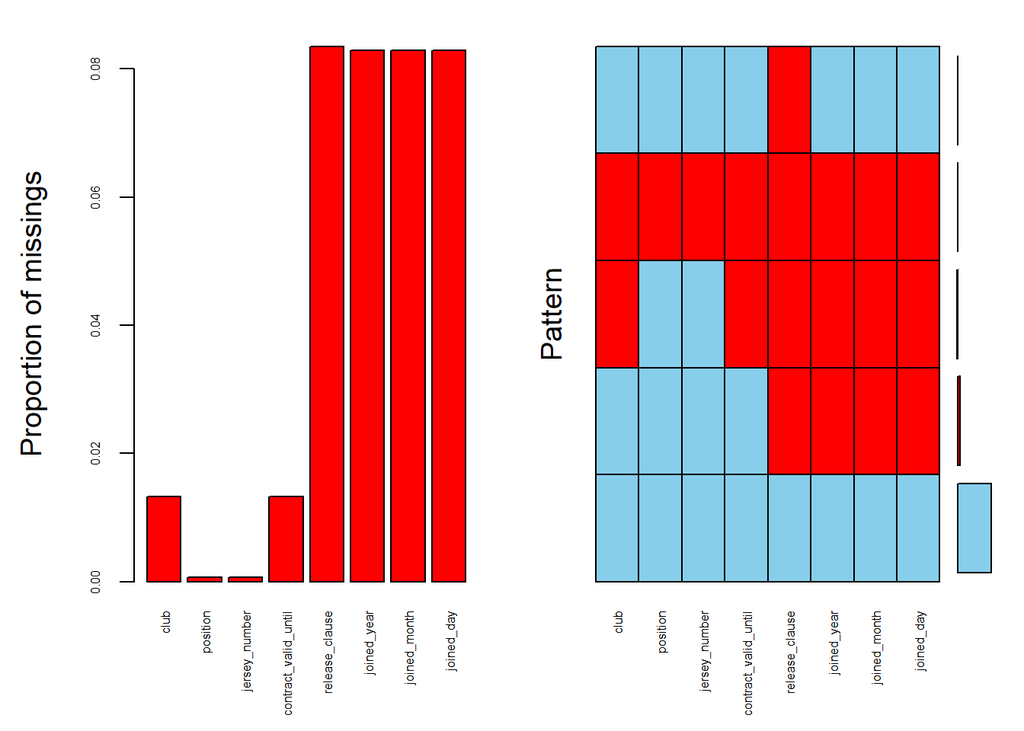

### 5.2 Điền các giá trị khuyết

Ta điền các giá trị khuyết cho biến câu lạc bộ (club) và biến release_clause

- club: Chuyển các giá trị khuyết thành Unknown (Có thể hiểu là chưa có hoặc chưa biết câu lạc bộ)
- release_clause: CHuyển giá trị khuyết thành Unknown và chuyển đổi thành 0

```r
cleaned_data <- cleaned_data |>
  mutate(across(everything(), ~ ifelse(is.na(club) & is.na(.), 'Unknown', .))) |>
  mutate(release_clause = as.numeric(ifelse(release_clause == 'Unknown', 0, release_clause)))
```

### 5.3 Điền giá trị khuyết bằng multiple imputation

Cuối cùng, điền các giá trị khuyết còn lại bằng Multiple Imputation

```r
imp_data <- mice(cleaned_data, 20, 'pmm', printFlag = TRUE)
final_data <- complete(imp_data, 5)
```

## 6.Outliers Remover:

Bằng một vài phương pháp như Histogram hay dùng bảng tóm tắt, ta có thể thấy biến wage và value bị lệch quá lớn vì có nhiều giá trị quá

cao, để phù hợp cho tính toán thống kê, ta sẽ dùng IQR để lọc các giá trị này đi.

Số dòng dữ liệu trước khi xử lý:

```
## [1] 18159
```

```r
final_data <- final_data |> filter(final_data$value > 0)
final_data <- final_data |> filter(final_data$wage > 0)

iqr_wage <- IQR(final_data$wage, na.rm = TRUE)
q1 <- quantile(final_data$wage, 0.25, na.rm = TRUE)
q3 <- quantile(final_data$wage, 0.75, na.rm = TRUE)

# Xác định ngưỡng
lower_bound <- q1 - 1.5 * iqr_wage
upper_bound <- q3 + 1.5 * iqr_wage

# Loại bỏ outliers
final_data <- final_data |>
  filter(wage >= lower_bound & wage <= upper_bound)

iqr_value <- IQR(final_data$value, na.rm = TRUE)
q1 <- quantile(final_data$value, 0.25, na.rm = TRUE)
q3 <- quantile(final_data$value, 0.75, na.rm = TRUE)

# Xác định ngưỡng
lower_bound <- q1 - 1.5 * iqr_value
upper_bound <- q3 + 1.5 * iqr_value

# Loại bỏ outliers
final_data <-final_data |>
  filter(value >= lower_bound & value <= upper_bound)
```

Dữ liệu còn lại khi xử lý Outliers:

```
## [1] 13823
```

## 7.Loại bỏ các Feature không cần thiết:

Một số biến không đóng góp nhiều cho dữ liệu hoặc khong cần thiết như:

```r
final_data <- final_data |> select(-c(joined_year, joined_month,joined_day))
```

# III. Khám phá dữ liệu

## 1.Bảng tóm tắt

```r
sum_data <- final_data |>
  clean_names(case = 'lower_camel')

# Tạo bảng tóm tắt cho đặc điểm cơ thể
summary_table <- sum_data |>
  summarise(across(c("age", "value", "releaseClause", "wage", "overall", "potential", "height", "weight","skillMoves"),
                   list(Min = min, Max = max, Median = median,
                      Mean = mean, SD = sd)))

summary_table <- summary_table |>
  gather(ten, gt) |>
  separate(ten, into = c("bien", "tk"), sep = "_") |>
  spread(tk, gt) |>
  select(bien, Min, Max, Median, Mean, SD)
summary_table
```

```
##            bien      Min      Max   Median         Mean          SD
## 1           age 16.00000  45.0000 24.00000 24.734717500 4.835704767
## 2        height  1.54940   2.0574  1.80340  1.812117182 0.067013549
## 3       overall 46.00000  82.0000 64.00000 63.585401143 5.192969477
## 4     potential 48.00000  89.0000 69.00000 69.322433625 5.026365973
## 5 releaseClause  0.00000  20.7000  0.86700  1.230119222 1.283859795
## 6    skillMoves  1.00000   5.0000  2.00000  2.219127541 0.666240664
## 7         value  0.01000   2.5000  0.50000  0.654242567 0.543504229
## 8          wage  0.00100   0.0210  0.00200  0.003531867 0.003478708
## 9        weight 49.89512 110.2229 74.84268 75.018761507 7.017914033
```

## 2.Biểu đồ phân phối

Ta dùng biểu đồ Histogram để trực quan hóa phân phối một số biến

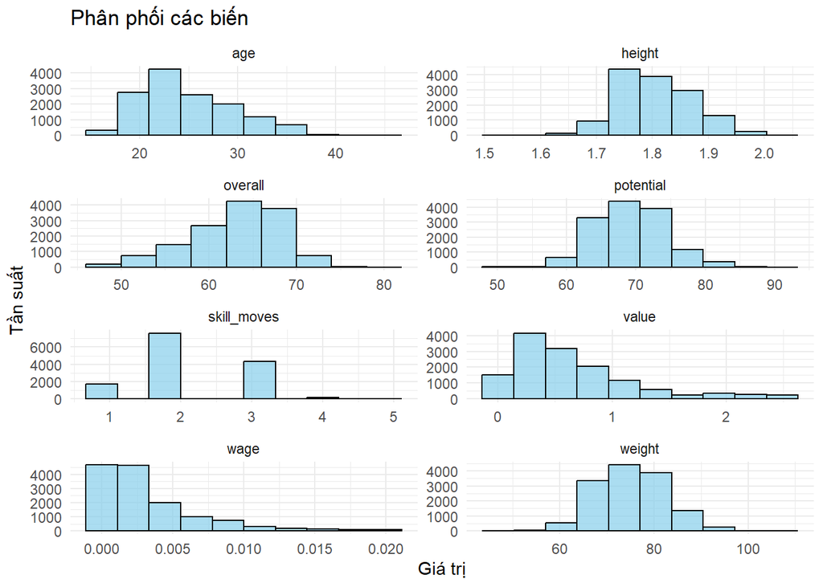

# IV. Kiểm định giả thuyết

Ta sẽ thực hiện một vài kiểm định giả thuyết để xem xét mối liên hệ giữa một vài thuộc tính

## 1.Chân thuận có ảnh hưởng đến mức lương ?

Ta xét giả thuyết và đối thuyết:

$H_0$: $u_L$ = $u_R$ (Trung bình mức lương của cầu thủ sử dụng chân trái và phải như nhau)

$H_1$: $u_L$ > $u_R$ (Trung bình mức lương của cầu thủ sử dụng chân trái tốt hơn chân phải)

### 1.1 Bảng tóm tắt dữ liệu:

```
## # A tibble: 2 × 4
##   preferred_foot     n    mean      sd
##   <chr>          <int>   <dbl>   <dbl>
## 1 Left            3153 0.00379 0.00359
## 2 Right          10670 0.00346 0.00344
```

**Nhận xét**: Nếu chỉ dựa vào bảng số liệu, ta có thể thấy trung bình lương của cầu thủ thuận chân trái cao hơn chân phải

### 1.2 A/B Testing:

Ta thực hiện A/B Testing kết hợp Permutation Test

#### 1.2.1 Biểu đồ chênh lệch

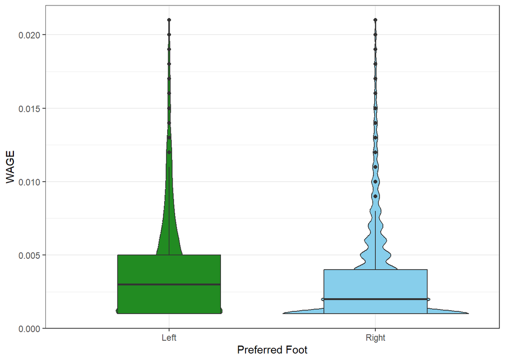

#### 1.2.2 Biểu đồ phân phối Histogram

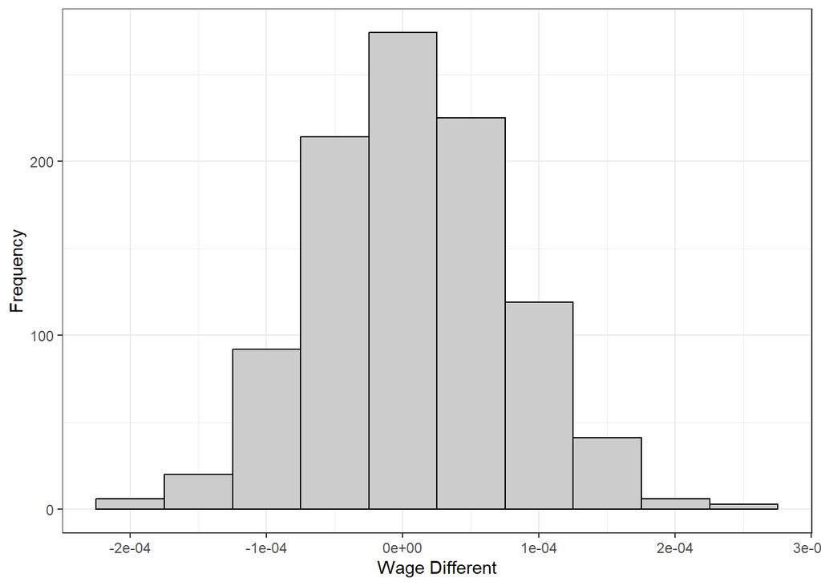

#### 1.2.3 p-value

```r
p_value_wage
```

```
## [1] 0
```

**Nhận xét**: Với mức ý nghĩa $alpha$ = 0.05, $p_{value}$ < alpha => Cầu thủ thuận chân trái có mức lương tốt hơn thuận chân phải

## 2.Chân thuận có ảnh hưởng đến khả năng kiểm soát bóng ?

Ta xét giả thuyết và đối thuyết:

$H_0$: $u_L$ = $u_R$ (Khả năng kiểm soát bóng của cầu thủ sử dụng chân trái và phải như nhau)

$H_1$: $u_L$ > $u_R$ (Khả năng kiểm soát bóng của cầu thủ sử dụng chân trái tốt hơn chân phải)

### 2.1 Bảng tóm tắt dữ liệu:

```
## # A tibble: 2 × 4
##   preferred_foot     n  mean    sd
##   <chr>          <int> <dbl> <dbl>
## 1 Left            3153  58.8  12.3
## 2 Right          10670  54.2  16.6
```

**Nhận xét**: Nếu chỉ dựa vào bảng số liệu, ta có thể thấy trung bình khả năng kiểm soát bóng của cầu thủ thuận chân trái cao hơn chân phải

### 2.2 A/B Testing:

Ta thực hiện A/B Testing kết hợp Permutation Test

#### 2.2.1 Biểu đồ chênh lệch

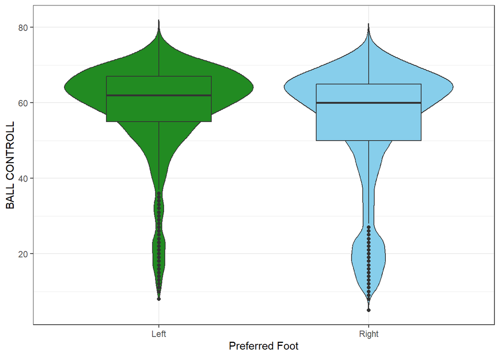

#### 2.2.2 Biểu đồ phân phối Histogram

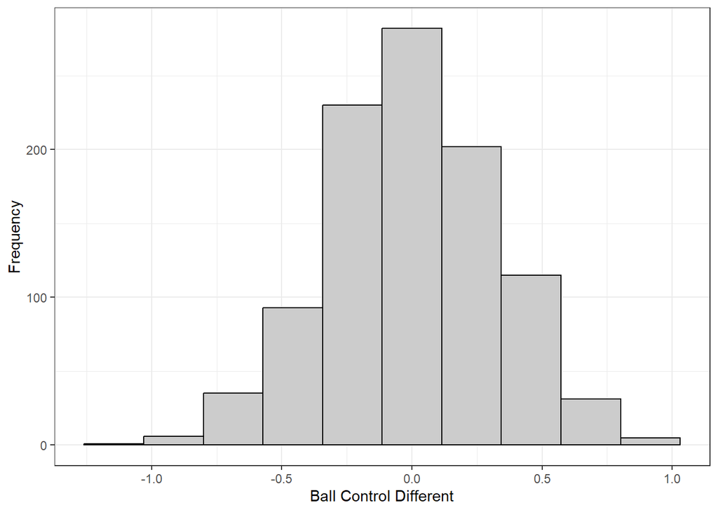

#### 2.2.3 p-value

```r
p_value_bc
```

```
## [1] 0
```

**Nhận xét**: Với mức ý nghĩa $alpha$ = 0.05, $p_{value}$ < alpha => Cầu thủ thuận chân trái kiểm soát bóng tốt hơn thuận chân phải

## 3.Chân thuận có ảnh hưởng đến lực sút hay không ?

Ta xét giả thuyết và đối thuyết:

$H_0$: $u_L$ = $u_R$ (Lực sút của cầu thủ sử dụng chân trái và phải như nhau)

$H_1$: $u_L$ > $u_R$ (Lực sút của cầu thủ sử dụng chân trái tốt hơn chân phải)

### 3.1 Bảng tóm tắt dữ liệu:

```
## # A tibble: 2 × 4
##   preferred_foot     n  mean    sd
##   <chr>          <int> <dbl> <dbl>
## 1 Left            3153  54.4  15.0
## 2 Right          10670  51.7  16.6
```

**Nhận xét**: Nếu chỉ dựa vào bảng số liệu, ta có thể thấy trung bình lực sút của cầu thủ thuận chân trái cao hơn chân phải

### 3.2 A/B Testing:

Ta thực hiện A/B Testing kết hợp Permutation Test

#### 3.2.1 Biểu đồ chênh lệch

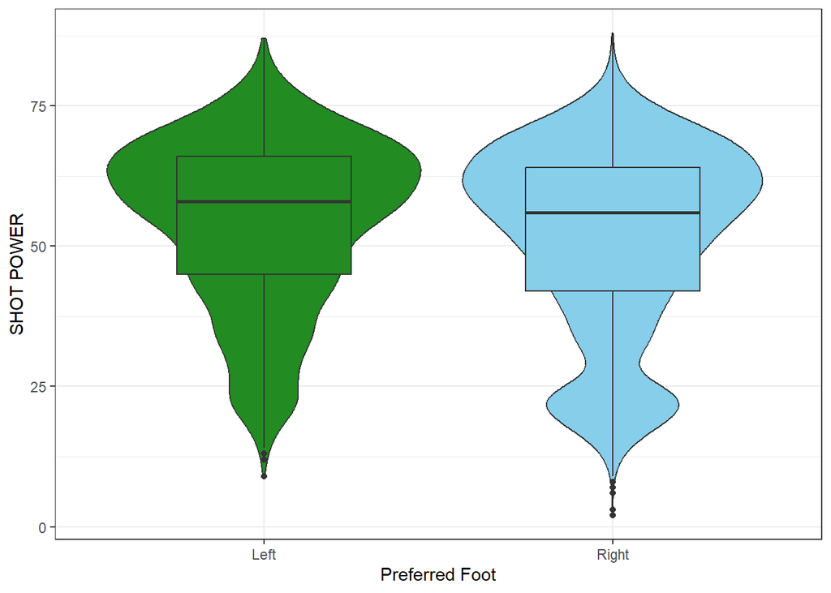

#### 3.2.2 Biểu đồ phân phối Histogram

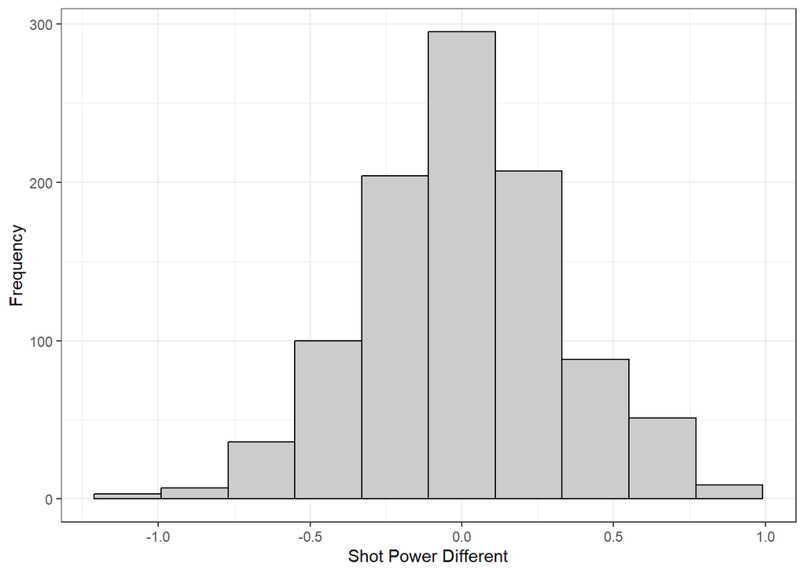

#### 3.2.3 p-value

```r
p_value_shot
```

```
## [1] 0
```

**Nhận xét**: Với mức ý nghĩa $alpha$ = 0.05, $p_{value}$ < alpha => Cầu thủ chân trái có lực sút hơn chân phải

## 4.Vị trí của cầu thủ có ảnh hưởng đến mức lương hay không ?

Ta xét giả thuyết và đối thuyết:

$H_0$: $u_{ThuMon}$ = $u_{TienDao}$ = $u_{TienVe}$ = $u_{HauVe}$ (Lương giữa các vị trí là như nhau)

$H_1$: $u_{ThuMon}$ $\neq$ $u_{TienDao}$ $\neq$ $u_{TienVe}$ $\neq$ $u_{HauVe}$ (Lương giữa các vị trí là khác nhau)

### 4.1 Kiểm tra và gom nhóm các vị trí

Ta sẽ kiểm tra xem có bao nhiêu vị trí cụ thể:

```
##    position
## 1        GK
## 2       LCB
## 3        RB
## 4        LB
## 5        CB
## 6       RDM
## 7       LCM
## 8        RS
## 9       RCB
## 10       CM
## 11      LDM
## 12      CDM
## 13       ST
## 14      RCM
## 15      CAM
## 16       LM
## 17       RW
## 18       LS
## 19      LAM
## 20      RAM
## 21      RWB
## 22       RM
## 23      LWB
## 24       CF
## 25       LF
## 26       LW
## 27       RF
```

Sau đó, ta sẽ gom nhóm theo 4 nhóm chính: Tiền đạo, Tiền vệ, Hậu vệ, Thủ môn

```r
# Nhóm vị trí
Tiendao <- c("RF", "ST", "LW", "LF", "RS", "LS", "RW", "CF")
Tienve <- c("RCM", "LDM", "CAM", "CDM", "RM", "LAM", "RDM", "CM", "RAM","LM","LCM")
Hauve <- c("RCB", "CB", "LCB", "LB", "RB", "RWB", "LWB")
Thumon <- c("GK")

pos_wage_data <- pos_wage_data |>
  mutate(
    position_group = case_when(
      position %in% Tiendao ~ "Striker",
      position %in% Tienve ~ "Midfield",
      position %in% Hauve ~ "Defender",
      position %in% Thumon ~ "GoalKeeper",
      TRUE ~ "None" # Nếu không thuộc nhóm nào
    )
  )
```

### 4.2 Bảng tóm tắt dữ liệu:

```
## # A tibble: 4 × 4
##   position_group     n    mean      sd
##   <chr>          <int>   <dbl>   <dbl>
## 1 Defender        4589 0.00360 0.00354
## 2 GoalKeeper      1692 0.00290 0.00314
## 3 Midfield        5020 0.00356 0.00347
## 4 Striker         2522 0.00378 0.00357
```

**Nhận xét**: Nếu chỉ dựa vào bảng số liệu, ta có thể thấy trung bình lương của Tiền đạo là cao nhất, sau đó đến lần lượt là Hậu vệ , Tiền vệ và cuối cùng là Thủ môn.

### 4.3 A/B Testing:

Ta thực hiện A/B Testing kết hợp Permutation Test

#### 4.3.1 Biểu đồ chênh lệch

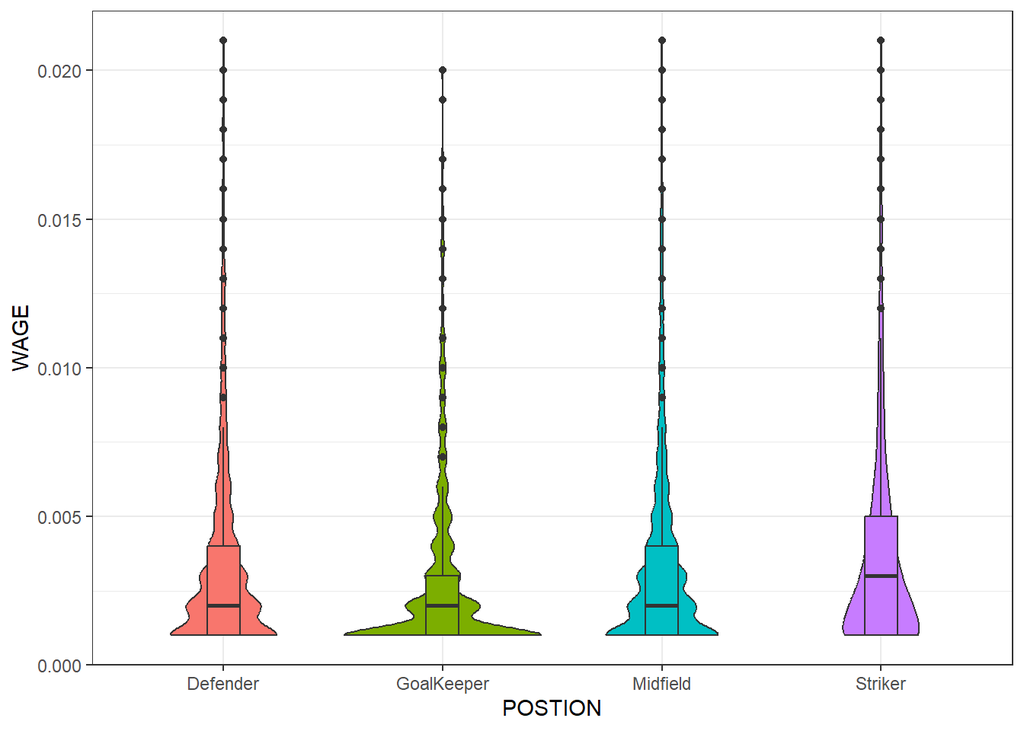

#### 4.3.2 p-value

```r
out_aov_3 <- aovp(formula = wage ~ position_group, data = pos_wage_data, perm = "Prob")
```

```
## [1] "Settings:  unique SS "
```

```r
summary(out_aov_3)
```

```
## Component 1 :
##                    Df R Sum Sq  R Mean Sq Iter  Pr(Prob)
## position_group1     3  0.00086 2.8679e-04 5000 < 2.2e-16 ***
## Residuals       13819  0.16640 1.2042e-05
## ---
## Signif. codes:  0 '***' 0.001 '**' 0.01 '*' 0.05 '.' 0.1 ' ' 1
```

**Nhận xét**: Với mức ý nghĩa $alpha$ = 0.05, $p_{value}$ < alpha => Các vị trí khác nhau sẽ có mức lương trung bình khác nhau.

## 5.Độ tuổi của cầu thủ có ảnh hưởng đến chỉ số tổng thể hay không ?

Ta xét giả thuyết và đối thuyết:

$H_0$: $u_{1}$ = $u_{2}$ = $u_{3}$ = $u_{4}$ (Trung bình tổng thể giữa các độ tuổi là như nhau)

$H_1$: $u_{1}$ $\neq$ $u_{2}$ $\neq$ $u_{3}$ $\neq$ $u_{4}$ (Trung bình tổng thể giữa các độ tuổi là khác nhau)

### 5.1 Kiểm tra và gom nhóm độ tuổi

Ta sẽ chia thành 4 độ tuổi dựa trên mức phân vị của dữ liệu.

```
##     25% 50% 75%
##  16  21  24  28  45
```

### 5.2 Bảng tóm tắt dữ liệu:

```
## # A tibble: 4 × 4
##   age_group     n  mean    sd
##   <chr>     <int> <dbl> <dbl>
## 1 (21, 24]   3040  63.7  4.16
## 2 (25, 28]   3330  65.6  3.63
## 3 (28, 45]   3185  66.9  3.81
## 4 [16 ,21]   4268  59.5  5.10
```

**Nhận xét**: Nếu chỉ dựa vào bảng số liệu, ta có thể thấy trung bình chỉ số tổng thể của độ tuổi 28 - 45 là cao nhất, sau đó đến lần lượt là 25 - 28, 21 - 24 và cuối cùng là 16 - 21.

### 5.3 A/B Testing:

Ta thực hiện A/B Testing kết hợp Permutation Test

#### 5.3.1 Biểu đồ chênh lệch

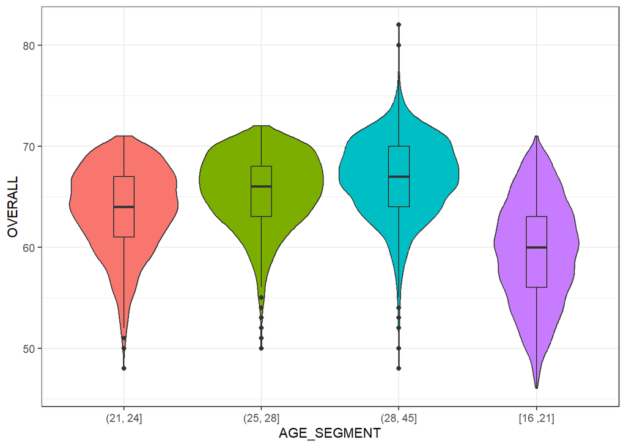

#### 5.3.2 p-value

```r
out_aov_2 <- aovp(formula = overall ~ age_group, data = overall_age, perm = "Prob")
```

```
## [1] "Settings:  unique SS "
```

```r
summary(out_aov_2)
```

```
## Component 1 :
##                Df R Sum Sq R Mean Sq Iter  Pr(Prob)
## age_group1      3   118849     39616 5000 < 2.2e-16 ***
## Residuals   13819   253888        18
## ---
## Signif. codes:  0 '***' 0.001 '**' 0.01 '*' 0.05 '.' 0.1 ' ' 1
```

**Nhận xét**: Với mức ý nghĩa $alpha$ = 0.05, $p_{value}$ < alpha => Các độ tuổi khác nhau sẽ có chỉ số tổng thể khác nhau.

# V. Mô hình hồi quy tuyến tính

## 1. Feature Engineering:

### 1.1 Biến Nationality:

Biến Nationality đang ở dạng phân loại, ta sẽ đưa biến về dạng số

```
## [1] "Nationality trước khi biến đổi: "
```

```
## [1] "Spain"     "Spain"     "Italy"     "Argentina" "Uruguay"
```

```
## [1] "Nationality sau khi biến đổi: "
```

```
## [1] 139 139  78   7 156
```

### 1.2 Biến club:

Biến Club đang ở dạng phân loại, ta sẽ đưa biến về dạng số

```
## [1] "Club trước khi biến đổi: "
```

```
## [1] "FC Porto"      "RCD Espanyol"  "Chievo Verona" "River Plate"
## [5] "FC Porto"
```

```
## [1] "Club sau khi biến đổi: "
```

```
## [1] 233 468 139 482 233
```

### 1.3 Biến prefered_foot:

Biến prefered_foot đang ở dạng phân loại, ta sẽ đưa biến về dạng số

```
## [1] "Chân thuận trước khi biến đổi: "
```

```
## [1] "Left"  "Right" "Right" "Left"  "Right"
```

```
## [1] "Chân thuận sau khi biến đổi: "
```

```
## [1] 0 1 1 0 1
```

### 1.4 Gom nhóm các vị trí:

Ta nhận thấy rằng, một vị trí khác nhau trên sân sẽ có những biến đáp ứng phù hợp khác nhau, nên ta sẽ gom nhóm và thực hiện mô hình theo từng vị trí.

```r
Tiendao <- c("RF", "ST", "LW", "LF", "RS", "LS", "RW", "CF")
Tienve <- c("RCM", "LDM", "CAM", "CDM", "RM", "LAM", "RDM", "CM", "RAM","LM","LCM")
Hauve <- c("RCB", "CB", "LCB", "LB", "RB", "RWB", "LWB")
Thumon <- c("GK")

final_data <- final_data |>
  mutate(
    position_group = case_when(
      position %in% Tiendao ~ "Striker",
      position %in% Tienve ~ "Midfield",
      position %in% Hauve ~ "Defender",
      position %in% Thumon ~ "GoalKeeper",
      TRUE ~ "None" # Nếu không thuộc nhóm nào
    )
  )

df<-final_data
```

## 2. Mô hình hồi quy cho tổng thể (Overall):

### 2.1 Thực hiện mô hình

Ta chỉ dùng các biến chỉ số (stats) của cầu thủ để dự đoán cho mô hình hồi quy dự đoán chỉ số Overall

```r
overall_feature <- names(df)
# Lấy tất cả các cột từ chỉ số của cầu thủ để hồi quy overall
overall_feature <- overall_feature[22:55]
overall_feature
```

```
##  [1] "crossing"         "finishing"        "heading_accuracy" "short_passing"
##  [5] "volleys"          "dribbling"        "curve"            "fk_accuracy"
##  [9] "long_passing"     "ball_control"     "acceleration"     "sprint_speed"
## [13] "agility"          "reactions"        "balance"          "shot_power"
## [17] "jumping"          "stamina"          "strength"         "long_shots"
## [21] "aggression"       "interceptions"    "positioning"      "vision"
## [25] "penalties"        "composure"        "marking"          "standing_tackle"
## [29] "sliding_tackle"   "gk_diving"        "gk_handling"      "gk_kicking"
## [33] "gk_positioning"   "gk_reflexes"
```

```r
overall_formula <- as.formula(paste("overall ~", paste(overall_feature, collapse = "+")))

# Chạy mô hình hồi quy tuyến tính với các biến đã chọn
overall_model <- lm(overall_formula, data = df)

# In kết quả của mô hình
summary(overall_model)
```

```
##
## Call:
## lm(formula = overall_formula, data = df)
##
## Residuals:
##      Min       1Q   Median       3Q      Max
## -12.6946  -1.5666   0.0263   1.6186  10.6457
##
## Coefficients:
##                    Estimate Std. Error t value Pr(>|t|)
## (Intercept)      15.5482215  0.3116881  49.884  < 2e-16 ***
## crossing          0.0255147  0.0028571   8.930  < 2e-16 ***
## finishing         0.0249122  0.0036442   6.836 8.48e-12 ***
## heading_accuracy  0.0901723  0.0030954  29.132  < 2e-16 ***
## short_passing     0.0633011  0.0049221  12.860  < 2e-16 ***
## volleys           0.0001586  0.0032008   0.050  0.96049
## dribbling         0.0092761  0.0043346   2.140  0.03237 *
## curve             0.0092908  0.0031015   2.996  0.00274 **
## fk_accuracy       0.0042769  0.0028238   1.515  0.12989
## long_passing     -0.0212367  0.0037228  -5.704 1.19e-08 ***
## ball_control      0.1388071  0.0052813  26.283  < 2e-16 ***
## acceleration      0.0245346  0.0041185   5.957 2.63e-09 ***
## sprint_speed      0.0202616  0.0038543   5.257 1.49e-07 ***
## agility           0.0092926  0.0030211   3.076  0.00210 **
## reactions         0.2239427  0.0041292  54.234  < 2e-16 ***
## balance          -0.0202140  0.0027711  -7.295 3.16e-13 ***
## shot_power        0.0210914  0.0031272   6.744 1.60e-11 ***
## jumping           0.0094578  0.0022195   4.261 2.05e-05 ***
## stamina           0.0182397  0.0025002   7.295 3.14e-13 ***
## strength          0.0405743  0.0026049  15.576  < 2e-16 ***
## long_shots       -0.0150189  0.0033795  -4.444 8.89e-06 ***
## aggression        0.0003776  0.0023840   0.158  0.87414
## interceptions     0.0005898  0.0034453   0.171  0.86407
## positioning      -0.0414167  0.0032819 -12.620  < 2e-16 ***
## vision           -0.0187179  0.0030505  -6.136 8.69e-10 ***
## penalties         0.0021793  0.0030231   0.721  0.47100
## composure         0.1023534  0.0032408  31.583  < 2e-16 ***
## marking           0.0337005  0.0027841  12.105  < 2e-16 ***
## standing_tackle   0.0270676  0.0052903   5.116 3.15e-07 ***
## sliding_tackle   -0.0216442  0.0049459  -4.376 1.22e-05 ***
## gk_diving         0.0599779  0.0063456   9.452  < 2e-16 ***
## gk_handling       0.0681598  0.0064758  10.525  < 2e-16 ***
## gk_kicking        0.0321502  0.0059805   5.376 7.75e-08 ***
## gk_positioning    0.0726863  0.0062922  11.552  < 2e-16 ***
## gk_reflexes       0.0784910  0.0063311  12.398  < 2e-16 ***
## ---
## Signif. codes:  0 '***' 0.001 '**' 0.01 '*' 0.05 '.' 0.1 ' ' 1
##
## Residual standard error: 2.48 on 13788 degrees of freedom
## Multiple R-squared:  0.7725, Adjusted R-squared:  0.772
## F-statistic:  1377 on 34 and 13788 DF,  p-value: < 2.2e-16
```

### 2.2 Biểu đồ giá trị thực tế và dự đoán

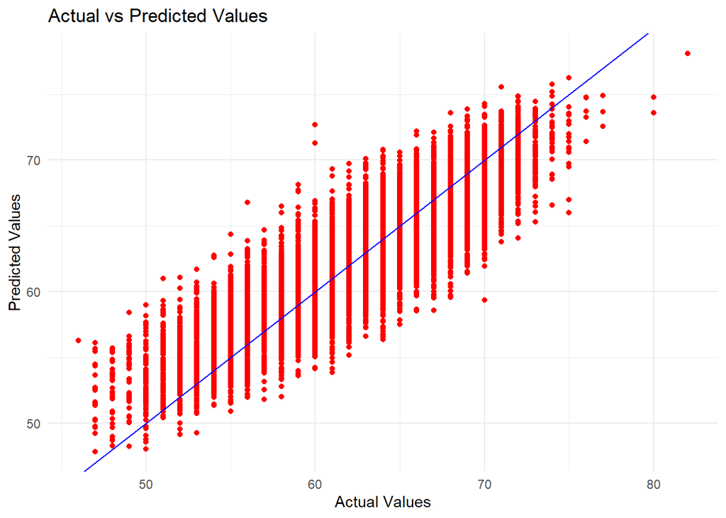

**Nhận xét**: Đường hồi quy của mô hình di chuyển khá khớp với các điểm dữ liệu

### 2.3 Một số chuẩn đoán cho mô hình

#### 2.3.1 Kiểm định tuyến tính mô hình

[figure not shown]

**Nhận xét**: Hình vẽ không cho thấy xu hướng một đường cong đáng kể

=> Giả định về tuyến tính của mô hình là phù hợp

#### 2.3.2 Kiểm tra tính đồng nhất phương sai

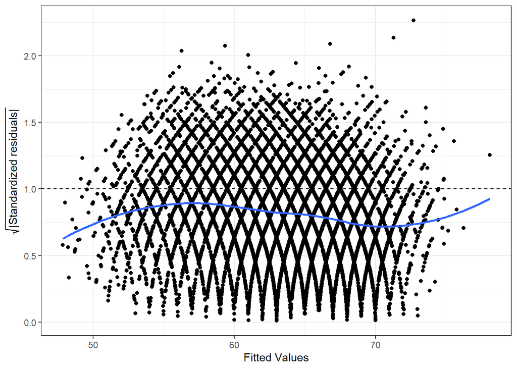

**Nhận xét**: Đường thẳng không xấp xỉ 1

=> Phương sai không đồng nhất

#### 2.3.3 Kiểm tra đa cộng tuyến

```r
vif(overall_model)
```

```
##         crossing        finishing heading_accuracy    short_passing
##         5.552935        10.172675         6.020769        10.520131
##          volleys        dribbling            curve      fk_accuracy
##         6.045662        13.836927         6.214723         4.622659
##     long_passing     ball_control     acceleration     sprint_speed
##         6.547098        15.664924         8.578576         7.293810
##          agility        reactions          balance       shot_power
##         4.434670         2.159674         3.406125         5.821774
##          jumping          stamina         strength       long_shots
##         1.514201         3.536436         2.398477         8.325097
##       aggression    interceptions      positioning           vision
##         3.619193        10.455563         8.247791         3.495460
##        penalties        composure          marking  standing_tackle
##         4.560617         2.442009         6.312105        27.229225
##   sliding_tackle        gk_diving      gk_handling       gk_kicking
##        22.700176        28.267235        26.931141        22.099031
##   gk_positioning      gk_reflexes
##        25.529147        28.870321
```

**Nhận xét**: Ta thấy mô hình xảy ra đa cộng tuyến ở nhiều biến, ta sẽ xử lý và khởi tạo lại mô hình

Ta sẽ loại bỏ biến có VIF cao nhất sau đó tính lại VIF của toàn bộ mô hình cho đến khi VIF của tất cả các biến đều < 10

```r
vif_values <- vif(overall_model)
while (max(vif_values) > 10) {
  high_vif_var <- names(which.max(vif_values))  # Tìm biến có VIF cao nhất
  # cat("Loại bỏ biến:", high_vif_var, "với VIF =", max(vif_values), "\n")

  # Loại bỏ biến có VIF cao nhất khỏi danh sách biến
  overall_feature <- overall_feature[!overall_feature %in% high_vif_var]

  # Cập nhật công thức hồi quy
  overall_formula <- as.formula(paste("overall ~", paste(overall_feature, collapse = "+")))

  # Chạy lại mô hình hồi quy
  overall_model <- lm(overall_formula, data = df)

  # Tính lại VIF
  vif_values <- vif(overall_model)
}
```

Ta có danh sách các biến sau khi xử lý

```
##  [1] "crossing"         "finishing"        "heading_accuracy" "short_passing"
##  [5] "volleys"          "curve"            "fk_accuracy"      "long_passing"
##  [9] "acceleration"     "sprint_speed"     "agility"          "reactions"
## [13] "balance"          "shot_power"       "jumping"          "stamina"
## [17] "strength"         "long_shots"       "aggression"       "interceptions"
## [21] "positioning"      "vision"           "penalties"        "composure"
## [25] "marking"          "gk_kicking"
```

Khởi tạo lại mô hình

```r
summary(overall_model)
```

```
##
## Call:
## lm(formula = overall_formula, data = df)
##
## Residuals:
##      Min       1Q   Median       3Q      Max
## -12.5126  -1.7105   0.0524   1.7540  10.6376
##
## Coefficients:
##                    Estimate Std. Error t value Pr(>|t|)
## (Intercept)      19.2760316  0.3207496  60.097  < 2e-16 ***
## crossing          0.0407148  0.0029721  13.699  < 2e-16 ***
## finishing         0.0297898  0.0038878   7.662 1.95e-14 ***
## heading_accuracy  0.0641490  0.0032356  19.826  < 2e-16 ***
## short_passing     0.1002124  0.0049568  20.217  < 2e-16 ***
## volleys          -0.0022428  0.0034697  -0.646 0.518039
## curve             0.0120754  0.0033503   3.604 0.000314 ***
## fk_accuracy      -0.0018164  0.0030515  -0.595 0.551681
## long_passing     -0.0162090  0.0040202  -4.032 5.56e-05 ***
## acceleration      0.0231739  0.0044449   5.214 1.88e-07 ***
## sprint_speed      0.0197895  0.0041772   4.737 2.19e-06 ***
## agility           0.0180110  0.0032491   5.543 3.02e-08 ***
## reactions         0.2796384  0.0042861  65.243  < 2e-16 ***
## balance          -0.0251754  0.0029986  -8.396  < 2e-16 ***
## shot_power        0.0248802  0.0033818   7.357 1.99e-13 ***
## jumping           0.0112348  0.0023877   4.705 2.56e-06 ***
## stamina           0.0122547  0.0027062   4.528 5.99e-06 ***
## strength          0.0486025  0.0028078  17.310  < 2e-16 ***
## long_shots       -0.0064530  0.0036516  -1.767 0.077224 .
## aggression       -0.0066004  0.0025616  -2.577 0.009984 **
## interceptions    -0.0009187  0.0029859  -0.308 0.758332
## positioning      -0.0399465  0.0034568 -11.556  < 2e-16 ***
## vision           -0.0103764  0.0032928  -3.151 0.001629 **
## penalties        -0.0013957  0.0032706  -0.427 0.669585
## composure         0.1203550  0.0034825  34.560  < 2e-16 ***
## marking           0.0246474  0.0028269   8.719  < 2e-16 ***
## gk_kicking        0.2140908  0.0037661  56.846  < 2e-16 ***
## ---
## Signif. codes:  0 '***' 0.001 '**' 0.01 '*' 0.05 '.' 0.1 ' ' 1
##
## Residual standard error: 2.691 on 13796 degrees of freedom
## Multiple R-squared:  0.7319, Adjusted R-squared:  0.7314
## F-statistic:  1449 on 26 and 13796 DF,  p-value: < 2.2e-16
```

**Nhận xét**:

- Mô hình cho ra R2-Score khá cao, chứng tỏ mô hình giải thích tốt cho biến mục tiêu
- Các biến có mối quan hệ tuyến tính.

##### Biểu đồ đường thẳng hồi quy

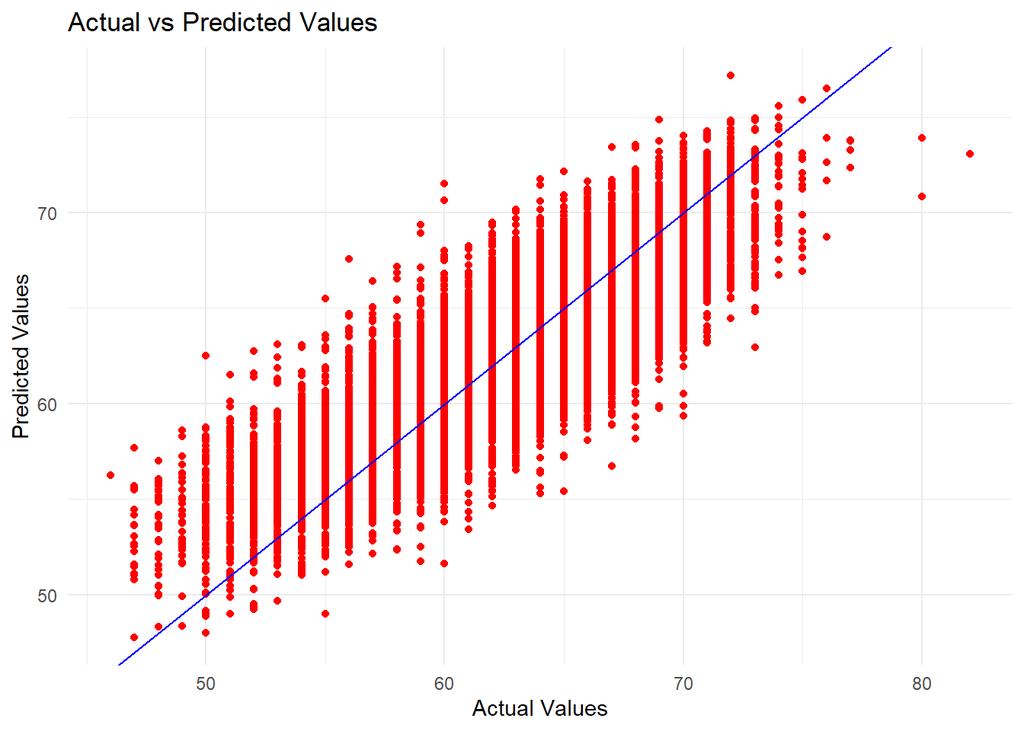

**Nhận xét**: Các điểm dữ liệu phân bố khá khớp với đường thẳng hồi quy

##### Kiểm định tuyến tính cho mô hình mới

[figure not shown]

**Nhận xét**: Đồ thị không cho thấy 1 xu hướng cong cụ thể

=> Giả định về mối liên hệ tuyến tính giữa các biến là phù hợp.

##### Kiểm định đồng nhất phương sai cho mô hình mới

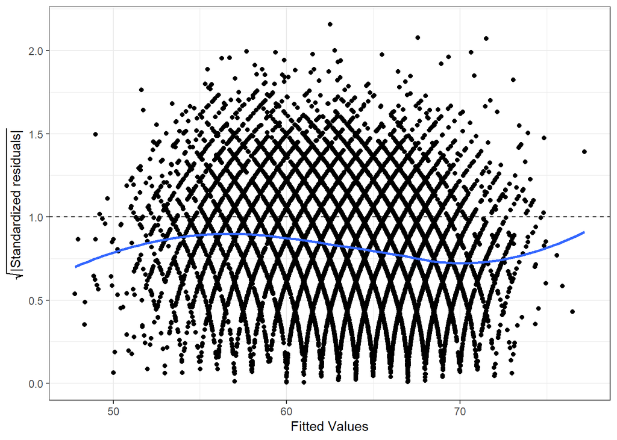

**Nhận xét**: Đồ thị chưa khớp lắm với đường thẳng 1

=> Giả định về đồng nhất phương sai là chưa phù hợp.

#### Đánh giá mô hình

##### RMSE của mô hình

```r
set.seed(5)  # Để tái tạo kết quả

# Chia dữ liệu thành tập huấn luyện và kiểm tra
train_index <- sample(seq_len(nrow(df)), size = 0.8 * nrow(df))  # 80% cho huấn luyện
train_data <- df[train_index, ]
test_data <- df[-train_index, ]

# Tạo mô hình hồi quy với các biến độc lập
overall_formula <- as.formula(paste("overall ~", paste(names(df)[22:55], collapse = "+")))
md_overall <- lm(overall_formula, data = train_data)

# Dự đoán trên tập kiểm tra
predictions <- predict(md_overall, newdata = test_data)

# Tính toán RMSE
actual_values <- test_data$overall
rmse <- sqrt(mean((actual_values - predictions)^2))
print(paste("RMSE từ tập kiểm tra: ", rmse))
```

```
## [1] "RMSE từ tập kiểm tra:  2.51080556990446"
```

#### R2 Score

```r
actual_values <- df$overall
predicted_values <- predict_overall
ss_res <- sum((actual_values - predicted_values)^2)
ss_tot <- sum((actual_values - mean(actual_values))^2)
r2 <- 1 - (ss_res / ss_tot)
print(paste("R2 Score của mô hình là:", r2))
```

```
## [1] "R2 Score của mô hình là: 0.731917085371723"
```

#### Áp dụng k-fold validation để tính RMSE

```r
set.seed(123)  # Để tái tạo kết quả
# áp dụng K-Fold Cross-Validation
k_fold_cv <- function(data, model_formula, k) {
  set.seed(123)  # Đảm bảo kết quả có thể tái tạo
  folds <- cut(seq(1, nrow(data)), breaks = k, labels = FALSE)  # Chia thành k nhóm
  errors <- numeric(k)  # Lưu trữ RMSE từng fold

  for (i in 1:k) {
    # Tách training và test set
    test_indices <- which(folds == i, arr.ind = TRUE)
    test_data <- data[test_indices, ]
    train_data <- data[-test_indices, ]

    # Huấn luyện mô hình
    model <- lm(model_formula, data = train_data)

    # Dự đoán
    predictions <- predict(model, newdata = test_data)

    # Tính RMSE của fold
    errors[i] <- sqrt(mean((test_data$overall - predictions)^2))
  }

  # Tính RMSE trung bình
  mean_rmse <- mean(errors)
  return(mean_rmse)
}

# Áp dụng K-Fold CV với k = 5
k <- 5
k_fold_result <- k_fold_cv(df, overall_formula, k)
```

```
## [1] "RMSE từ K-Fold CV (k = 5 ): 2.98007900900518"
```

## 3. Mô hình hồi quy cho từng vị trí

### Phân chia dữ liệu:

Tách dữ liệu theo từng vị trí:

```r
df_gk_numeric<-df[df$position_group == "GoalKeeper", ]
df_st_numeric <- df[df$position_group == "Striker", ]
df_mid_numeric <- df[df$position_group == "Midfield", ]
df_df_numeric <- df[df$position_group == "Defender", ]
```

Các vị trí như Tiền đạo, hậu vệ, tiền vệ sẽ không cần các chỉ số của Thủ môn, nên ta sẽ loại bỏ các biến này

```r
df_st_numeric <- df_st_numeric |> select(-c(gk_diving, gk_handling, gk_kicking, gk_positioning, gk_reflexes))
df_mid_numeric <- df_mid_numeric |> select(-c(gk_diving, gk_handling, gk_kicking, gk_positioning, gk_reflexes))
df_df_numeric <- df_df_numeric |> select(-c(gk_diving, gk_handling, gk_kicking, gk_positioning, gk_reflexes))
```

### 3.1 Mô hình hồi quy cho Goal Keeper:

#### 3.1.1 Lựa chọn biến phù hợp với mô hình

```r
df_gk_numeric <- df_gk_numeric |> select_if(is.numeric)
# Tìm các biến phụ thuộc tuyến tính
lin_combos <- findLinearCombos(df_gk_numeric)
# Loại bỏ các biến phụ thuộc tuyến tính (nếu có)
if (!is.null(lin_combos$remove)) {
  df_gk_cleaned <- df_gk_numeric[, -lin_combos$remove]
} else {
  df_gk_cleaned <- df_gk_numeric
}

# Loại bỏ các biến không có ý nghĩa
df_gk_numeric <- df_gk_cleaned |> select(-c(id,nationality,club))
```

Dùng Stepwise để lựa chọn các biến phù hợp

```r
# Chạy stepwise để giảm số lượng biến
md_full <- lm(wage ~ ., data = df_gk_numeric)
step_md <- step(md_full, direction = "both")

# Lấy danh sách biến từ stepwise
selected_vars <- names(coef(step_md))[-1]
# Giới hạn dữ liệu chỉ chứa các biến đã chọn
df_gk_numeric <- df_gk_numeric[, c("wage", selected_vars)]
```

Các biến lựa chọn là

```
##  [1] "age"                      "overall"
##  [3] "value"                    "preferred_foot"
##  [5] "international_reputation" "height"
##  [7] "crossing"                 "short_passing"
##  [9] "fk_accuracy"              "long_passing"
## [11] "sprint_speed"             "reactions"
## [13] "jumping"                  "aggression"
## [15] "positioning"              "gk_diving"
## [17] "gk_handling"              "gk_kicking"
## [19] "gk_reflexes"              "release_clause"
```

#### 3.1.2 Biểu đồ RMSE theo các biến đã chọn

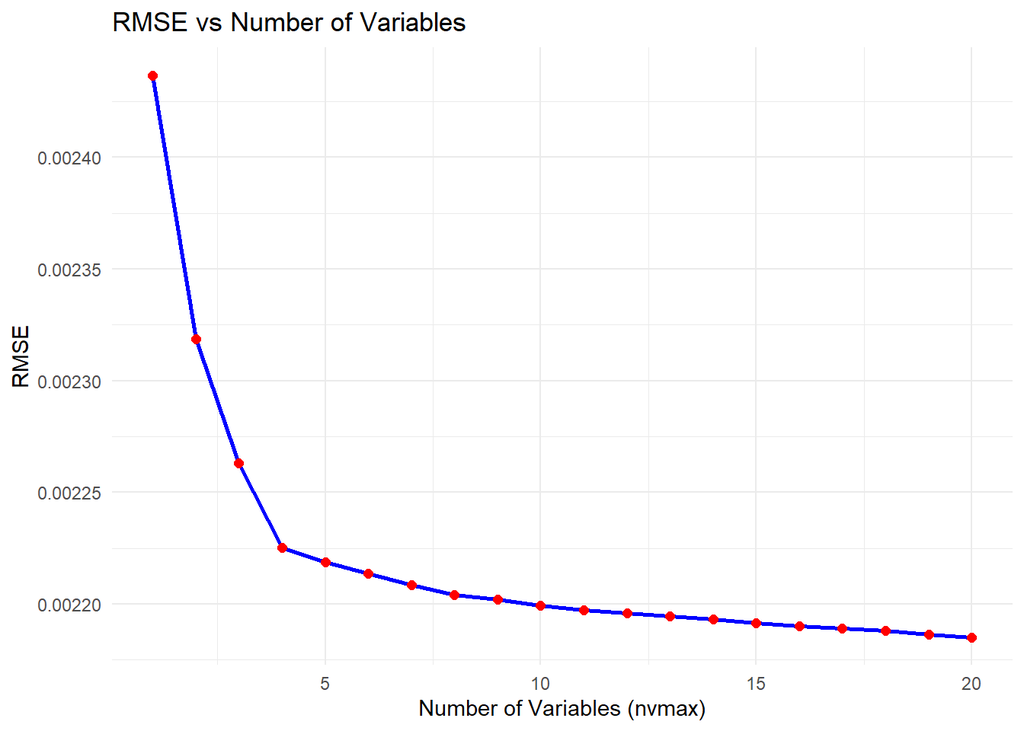

**Nhận xét**: Vậy, các biến trên là các biến phù hợp

#### 3.1.3 Áp dụng mô hình cho các biến đã chọn

```
##
## Call:
## lm(formula = gk_formula_final, data = df_gk_numeric)
##
## Residuals:
##        Min         1Q     Median         3Q        Max
## -0.0097387 -0.0011483 -0.0001715  0.0005556  0.0118618
##
## Coefficients:
##                            Estimate Std. Error t value Pr(>|t|)
## (Intercept)              -1.159e-02  2.490e-03  -4.654 3.51e-06 ***
## age                       1.115e-04  1.542e-05   7.226 7.53e-13 ***
## overall                  -1.577e-04  6.708e-05  -2.351  0.01885 *
## value                     1.722e-03  2.458e-04   7.005 3.57e-12 ***
## preferred_foot           -4.901e-04  1.809e-04  -2.709  0.00681 **
## international_reputation  2.310e-03  3.270e-04   7.066 2.33e-12 ***
## height                    2.709e-03  1.224e-03   2.213  0.02700 *
## crossing                 -3.399e-05  1.616e-05  -2.104  0.03555 *
## short_passing             1.786e-05  9.401e-06   1.900  0.05760 .
## fk_accuracy              -2.411e-05  1.369e-05  -1.761  0.07836 .
## long_passing             -1.959e-05  9.263e-06  -2.115  0.03461 *
## sprint_speed              9.359e-06  6.581e-06   1.422  0.15519
## reactions                 2.424e-05  1.211e-05   2.001  0.04557 *
## jumping                   1.079e-05  5.888e-06   1.832  0.06712 .
## aggression                1.813e-05  7.918e-06   2.290  0.02216 *
## positioning              -3.144e-05  1.593e-05  -1.973  0.04860 *
## gk_diving                 5.177e-05  2.346e-05   2.207  0.02746 *
## gk_handling               6.316e-05  2.441e-05   2.588  0.00975 **
## gk_kicking                2.536e-05  1.227e-05   2.066  0.03894 *
## gk_reflexes               4.263e-05  2.332e-05   1.828  0.06771 .
## release_clause            7.777e-04  8.677e-05   8.962  < 2e-16 ***
## ---
## Signif. codes:  0 '***' 0.001 '**' 0.01 '*' 0.05 '.' 0.1 ' ' 1
##
## Residual standard error: 0.002199 on 1671 degrees of freedom
## Multiple R-squared:  0.5144, Adjusted R-squared:  0.5086
## F-statistic: 88.49 on 20 and 1671 DF,  p-value: < 2.2e-16
```

**Nhận xét**:

#### 3.1.4 Biểu đồ hồi quy

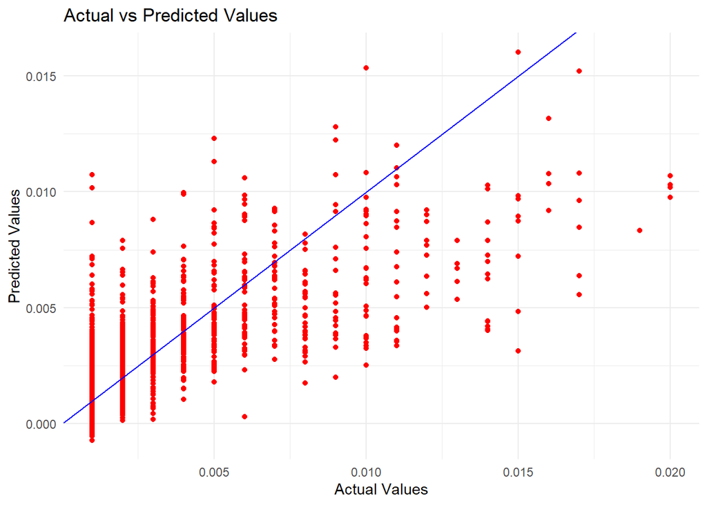

```r
gk_predict_wage <- predict(gk_model_final, newdata = df_gk_numeric)

# Vẽ biểu đồ dự đoán so với giá trị thực tế
result <- data.frame(actual_values = df_gk_numeric$wage, predictions = gk_predict_wage)

ggplot(result, aes(x = actual_values, y = predictions)) +
  geom_point(color = "red") +
  geom_abline(slope = 1, intercept = 0, color = "blue") +
  labs(
    title = "Actual vs Predicted Values",
    x = "Actual Values",
    y = "Predicted Values"
  ) +
  theme_minimal()
```

**Nhận xét**: Đường thẳng hồi quy biểu diễn tương đối với các điểm dữ liệu

#### 3.1.5 Một số chuẩn đoán cho mô hình

##### Kiểm định tuyến tính mô hình

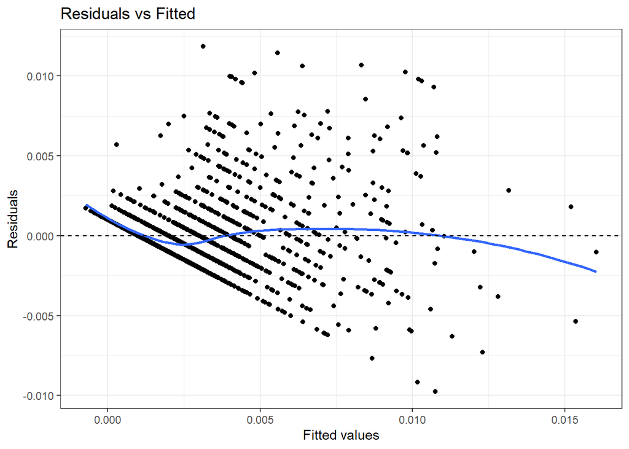

=> Giả định về tuyến tính của mô hình là phù hợp

##### Kiểm định đồng nhất phương sai

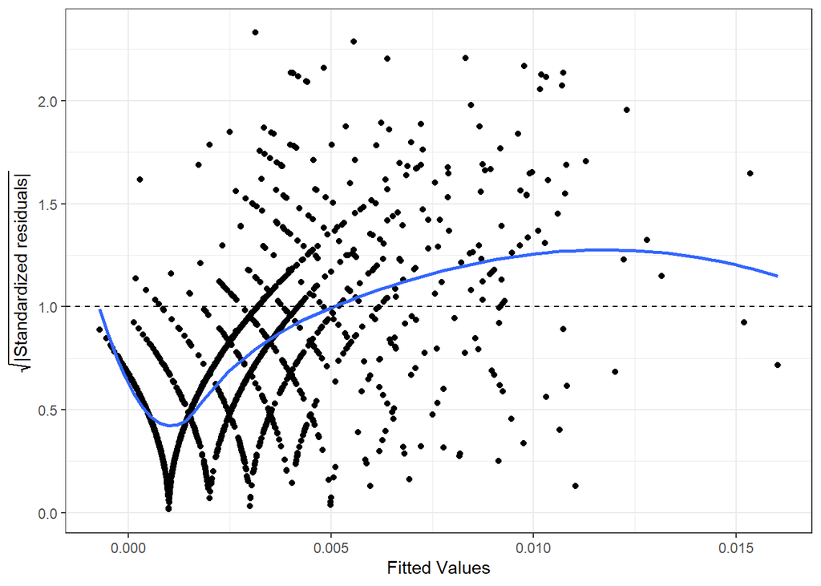

##### Kiểm tra đa cộng tuyến

```r
vif(gk_model_final)
```

```
##                      age                  overall                    value
##                 2.596561                56.505673                 5.164010
##           preferred_foot international_reputation                   height
##                 1.013492                 1.105917                 1.181392
##                 crossing            short_passing              fk_accuracy
##                 1.368357                 1.771253                 1.303557
##             long_passing             sprint_speed                reactions
##                 1.808481                 1.712632                 4.374103
##                  jumping               aggression              positioning
##                 1.538672                 1.281525                 1.609333
##                gk_diving              gk_handling               gk_kicking
##                 7.476621                 7.696001                 2.251985
##              gk_reflexes           release_clause
##                 8.447414                 3.488636
```

**Nhận xét**: Mô hình xảy ra đa cộng tuyến ở biến overall.

Ta tiến hành loại bỏ biến overall và kiểm tra lại

```
##                      age                    value           preferred_foot
##                 2.320695                 5.067770                 1.011842
## international_reputation                   height                 crossing
##                 1.103342                 1.175525                 1.368248
##            short_passing              fk_accuracy             long_passing
##                 1.770692                 1.303294                 1.807804
##             sprint_speed                reactions                  jumping
##                 1.710127                 2.560989                 1.531539
##               aggression              positioning                gk_diving
##                 1.280815                 1.608977                 4.275816
##              gk_handling               gk_kicking              gk_reflexes
##                 2.856944                 1.933599                 4.358233
##           release_clause
##                 3.488086
```

**Nhận xét**: Mô hình đã không còn đa cộng tuyến

#### 3.1.6 Đánh giá mô hình

##### RMSE của mô hình

```r
set.seed(5)  # Để tái tạo kết quả

# Chia dữ liệu thành tập huấn luyện và kiểm tra (80% huấn luyện, 20% kiểm tra)
train_index <- sample(seq_len(nrow(df_gk_numeric)), size = 0.8 * nrow(df_gk_numeric))
train_data <- df_gk_numeric[train_index, ]
test_data <- df_gk_numeric[-train_index, ]

# Tạo công thức mô hình với các biến đã chọn
gk_formula_final <- as.formula(paste("wage ~", paste(gk_best_vars, collapse = "+")))

# Huấn luyện mô hình hồi quy tuyến tính
gk_model_final <- lm(gk_formula_final, data = train_data)

# Dự đoán trên tập kiểm tra
gk_predictions <- predict(gk_model_final, newdata = test_data)

actual_values <- test_data$wage
rmse <- sqrt(mean((actual_values - gk_predictions)^2))
print(paste("RMSE từ tập kiểm tra: ", rmse))
```

```
## [1] "RMSE từ tập kiểm tra:  0.00256435044984539"
```

#### R2 Score

```r
actual_values <- df_gk_numeric$wage
predicted_values <- gk_predict_wage
ss_res <- sum((actual_values - predicted_values)^2)
ss_tot <- sum((actual_values - mean(actual_values))^2)
r2 <- 1 - (ss_res / ss_tot)
print(paste("R2 Score của mô hình là:", r2))
```

```
## [1] "R2 Score của mô hình là: 0.514365677274622"
```

#### Áp dụng k-fold validation để tính RMSE

```r
#sử dụng K-Fold Cross-Validation
k_fold_cv <- function(data, model_formula, k) {
  set.seed(123)  # Đảm bảo kết quả có thể tái tạo
  folds <- cut(seq(1, nrow(data)), breaks = k, labels = FALSE)  # Chia thành k nhóm
  errors <- numeric(k)  # Lưu trữ RMSE từng fold

  for (i in 1:k) {
    # Tách training và test set
    test_indices <- which(folds == i, arr.ind = TRUE)
    test_data <- data[test_indices, ]
    train_data <- data[-test_indices, ]

    # Huấn luyện mô hình trên training set
    model <- lm(model_formula, data = train_data)

    # Dự đoán trên test set
    predictions <- predict(model, newdata = test_data)

    # Tính RMSE của fold
    errors[i] <- sqrt(mean((test_data$wage - predictions)^2))
  }

  # Tính RMSE trung bình của tất cả các folds
  mean_rmse <- mean(errors)
  return(mean_rmse)
}

# Áp dụng K-Fold CV với k = 5
k <- 5
k_fold_result <- k_fold_cv(df_gk_numeric, gk_formula_final, k)
```

```
## [1] "RMSE từ K-Fold CV (k = 5 ): 0.00223102431213675"
```

#### 3.1.7 Mở rộng mô hình

##### Khởi tạo mô hình

Ta sẽ tiến hành chạy mô hình bậc 2 với các biến có ít độ tuyến tính với mô hình

```r
coeffs <- summary(gk_model_final)$coefficients

if (is.matrix(coeffs)) {
  p_values <- coeffs[, "Pr(>|t|)"]
} else {
  # Khi chỉ có một biến độc lập
  p_values <- coeffs["Pr(>|t|)"]
}

# Loại bỏ hệ số intercept (nếu cần)
p_values <- p_values[-1]  # Loại bỏ dòng đầu tiên (Intercept)

# Phân loại biến theo p-value
gk_2 <- names(p_values[p_values > 0.05])  # Biến có p-value > 0.05
gk_1 <- names(p_values[p_values <= 0.05]) # Biến có p-value <= 0.05

gk_best_vars_1 <- gk_best_vars[gk_best_vars %in% gk_1]
gk_best_vars_2 <- gk_best_vars[gk_best_vars %in% gk_2]
gk_formula_final <- as.formula(paste("wage ~",
                                     paste(gk_best_vars_1, collapse = "+"),
                                     "+",
                                     paste(paste0("I(", gk_best_vars_2, "^2)"), collapse = "+")))

# Chạy mô hình hồi quy tuyến tính bậc hai
gk_model_final <- lm(gk_formula_final, data = df_gk_numeric)
```

```r
# In kết quả của mô hình
summary(gk_model_final)
```

```
##
## Call:
## lm(formula = gk_formula_final, data = df_gk_numeric)
##
## Residuals:
##        Min         1Q     Median         3Q        Max
## -0.0097105 -0.0011449 -0.0001802  0.0006286  0.0119582
##
## Coefficients:
##                            Estimate Std. Error t value Pr(>|t|)
## (Intercept)              -1.008e-02  2.420e-03  -4.164 3.28e-05 ***
## age                       8.915e-05  1.485e-05   6.003 2.36e-09 ***
## value                     1.476e-03  2.502e-04   5.900 4.39e-09 ***
## international_reputation  2.213e-03  3.272e-04   6.764 1.85e-11 ***
## height                    2.348e-03  1.219e-03   1.925  0.05435 .
## short_passing             1.246e-05  9.318e-06   1.337  0.18133
## jumping                   1.069e-05  5.858e-06   1.825  0.06820 .
## release_clause            7.745e-04  8.681e-05   8.921  < 2e-16 ***
## I(preferred_foot^2)      -4.939e-04  1.808e-04  -2.732  0.00636 **
## I(crossing^2)            -9.240e-07  4.554e-07  -2.029  0.04261 *
## I(fk_accuracy^2)         -5.379e-07  2.764e-07  -1.946  0.05178 .
## I(long_passing^2)        -1.896e-07  1.554e-07  -1.221  0.22244
## I(sprint_speed^2)         9.518e-08  8.511e-08   1.118  0.26358
## I(reactions^2)            1.047e-07  8.464e-08   1.237  0.21609
## I(aggression^2)           2.722e-07  1.376e-07   1.978  0.04806 *
## I(positioning^2)         -1.445e-06  6.518e-07  -2.217  0.02679 *
## I(gk_diving^2)            1.524e-07  1.442e-07   1.057  0.29074
## I(gk_handling^2)          2.042e-07  1.230e-07   1.660  0.09701 .
## I(gk_kicking^2)           1.395e-07  9.516e-08   1.466  0.14280
## I(gk_reflexes^2)          5.438e-08  1.341e-07   0.406  0.68510
## ---
## Signif. codes:  0 '***' 0.001 '**' 0.01 '*' 0.05 '.' 0.1 ' ' 1
##
## Residual standard error: 0.002199 on 1672 degrees of freedom
## Multiple R-squared:  0.514,  Adjusted R-squared:  0.5085
## F-statistic: 93.07 on 19 and 1672 DF,  p-value: < 2.2e-16
```

##### Đường thẳng hồi quy

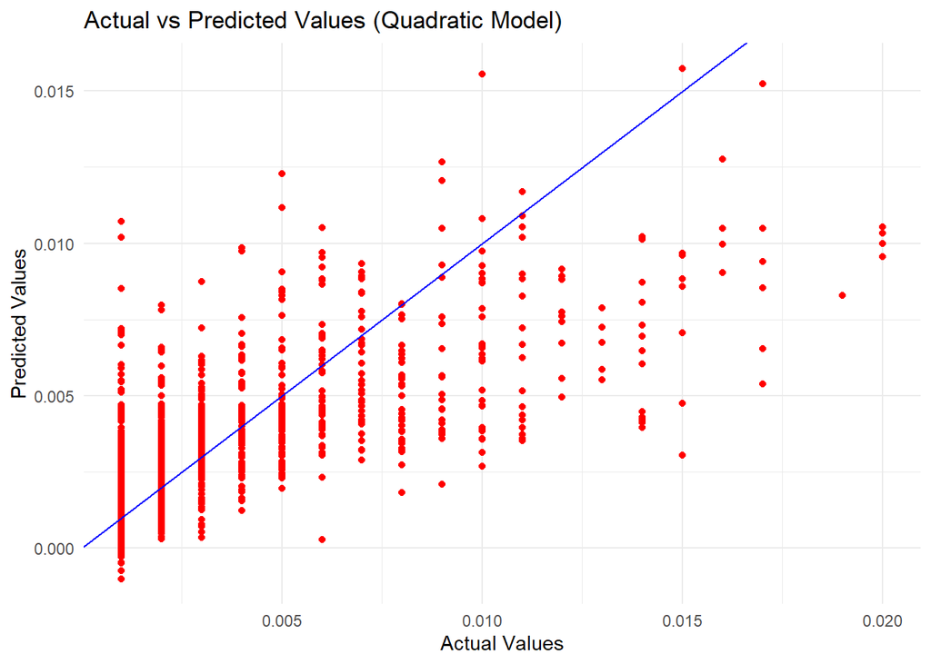

##### Đánh giá mô hình

```
## [1] "RMSE từ tập kiểm tra (Quadratic Model): 0.00254333826534467"
```

```
## [1] "R2 Score của mô hình bậc hai là: 0.514004847197236"
```

### 3.2 Mô hình hồi quy dự đoán mức lương cho vị trí Tiền đạo

#### 3.2.1 Lựa chọn biến phù hợp cho mô hình

```r
# Tìm các biến phụ thuộc tuyến tính
df_st_numeric <- df_st_numeric |> select_if(is.numeric)
lin_combos <- findLinearCombos(df_st_numeric)
# Loại bỏ các biến phụ thuộc tuyến tính (nếu có)
if (!is.null(lin_combos$remove)) {
  df_st_cleaned <- df_st_numeric[, -lin_combos$remove]
} else {
  df_st_cleaned <- df_st_numeric
}

# Loại bỏ các biến không có ý nghĩa
df_st_numeric <- df_st_cleaned |> select(-c(id, nationality, club))
```

Dùng Stepwise để lựa chọn các biến phù hợp:

```r
# Chạy stepwise để giảm số lượng biến
md_full <- lm(wage ~ ., data = df_st_numeric)
step_md <- step(md_full, direction = "both")
# Lấy danh sách biến từ stepwise
selected_vars <- names(coef(step_md))[-1]
```

Các biến phù hợp để khởi tạo mô hình là:

```r
print(selected_vars)
```

```
##  [1] "age"                      "value"
##  [3] "international_reputation" "body_type"
##  [5] "crossing"                 "short_passing"
##  [7] "volleys"                  "fk_accuracy"
##  [9] "sprint_speed"             "long_shots"
## [11] "interceptions"            "penalties"
## [13] "marking"                  "release_clause"
```

#### 3.2.2 Biểu đồ RMSE cho các biến đã chọn

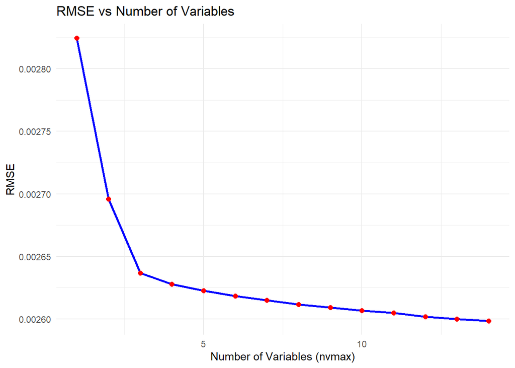

**Nhận xét**: Vậy, các biến trên được chọn để khởi tạo mô hình là phù hợp

#### 3.2.3 Áp dụng mô hình cho các biến đã chọn

```
##
## Call:
## lm(formula = st_formula_final, data = df_st_numeric)
##
## Residuals:
##        Min         1Q     Median         3Q        Max
## -0.0176715 -0.0013709 -0.0003599  0.0006923  0.0160337
##
## Coefficients:
##                            Estimate Std. Error t value Pr(>|t|)
## (Intercept)              -2.586e-03  8.486e-04  -3.048 0.002328 **
## age                       9.241e-05  1.547e-05   5.974 2.65e-09 ***
## value                     1.515e-03  1.720e-04   8.811  < 2e-16 ***
## international_reputation  1.229e-03  3.695e-04   3.327 0.000890 ***
## body_type                -5.625e-05  2.991e-05  -1.881 0.060135 .
## crossing                  2.538e-05  6.476e-06   3.919 9.13e-05 ***
## short_passing            -2.616e-05  1.026e-05  -2.549 0.010871 *
## volleys                   1.752e-05  7.909e-06   2.215 0.026845 *
## fk_accuracy              -1.468e-05  5.748e-06  -2.554 0.010707 *
## sprint_speed             -2.052e-05  5.649e-06  -3.632 0.000287 ***
## long_shots                2.379e-05  9.412e-06   2.528 0.011522 *
## interceptions             1.593e-05  5.769e-06   2.761 0.005812 **
## penalties                 1.257e-05  7.578e-06   1.659 0.097302 .
## marking                  -1.289e-05  5.324e-06  -2.421 0.015563 *
## release_clause            1.008e-03  5.618e-05  17.938  < 2e-16 ***
## ---
## Signif. codes:  0 '***' 0.001 '**' 0.01 '*' 0.05 '.' 0.1 ' ' 1
##
## Residual standard error: 0.002606 on 2507 degrees of freedom
## Multiple R-squared:  0.4698, Adjusted R-squared:  0.4668
## F-statistic: 158.6 on 14 and 2507 DF,  p-value: < 2.2e-16
```

**Nhận xét**:

- R2 Score: mô hình giải thích tương đối cho biến mục tiêu
- Một số biến ảnh hưởng mạnh đến wage của vị trí Tiền đạo: age, value, crossing.
- Một số biến không ảnh hưởng nhiều đến mô hình: body_type, penalties.

#### 3.2.4 Biểu đồ hồi quy

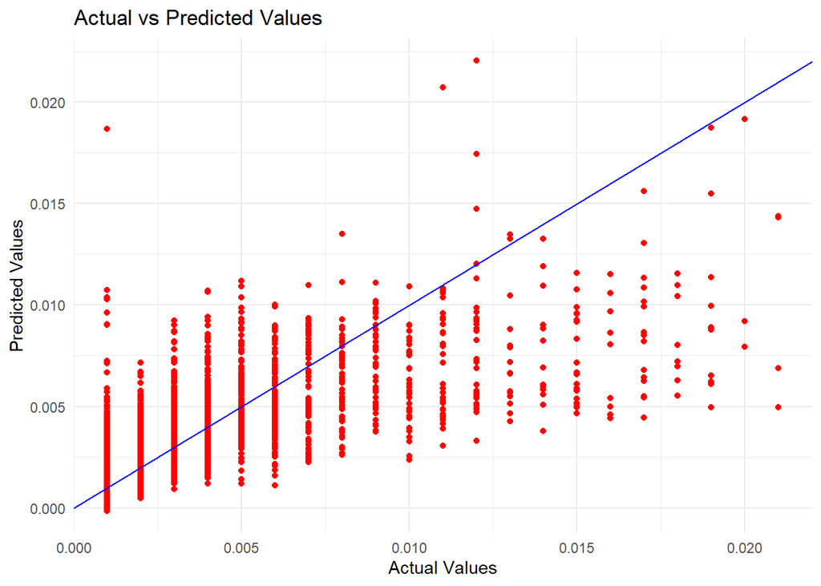

```r
# Dự đoán với mô hình mới
st_predict_wage <- predict(st_model_final, newdata = df_st_numeric)

# Vẽ biểu đồ dự đoán so với giá trị thực tế
result <- data.frame(actual_values = df_st_numeric$wage, predictions = st_predict_wage)

ggplot(result, aes(x = actual_values, y = predictions)) +
  geom_point(color = "red") +
  geom_abline(slope = 1, intercept = 0, color = "blue") +
  labs(
    title = "Actual vs Predicted Values",
    x = "Actual Values",
    y = "Predicted Values"
  ) +
  theme_minimal()
```

**Nhận xét**: Đường thẳng hồi quy không quá khớp với dữ liệu.

#### 3.2.5 Một số chuẩn đoán cho mô hình

##### Kiểm định tuyến tính mô hình

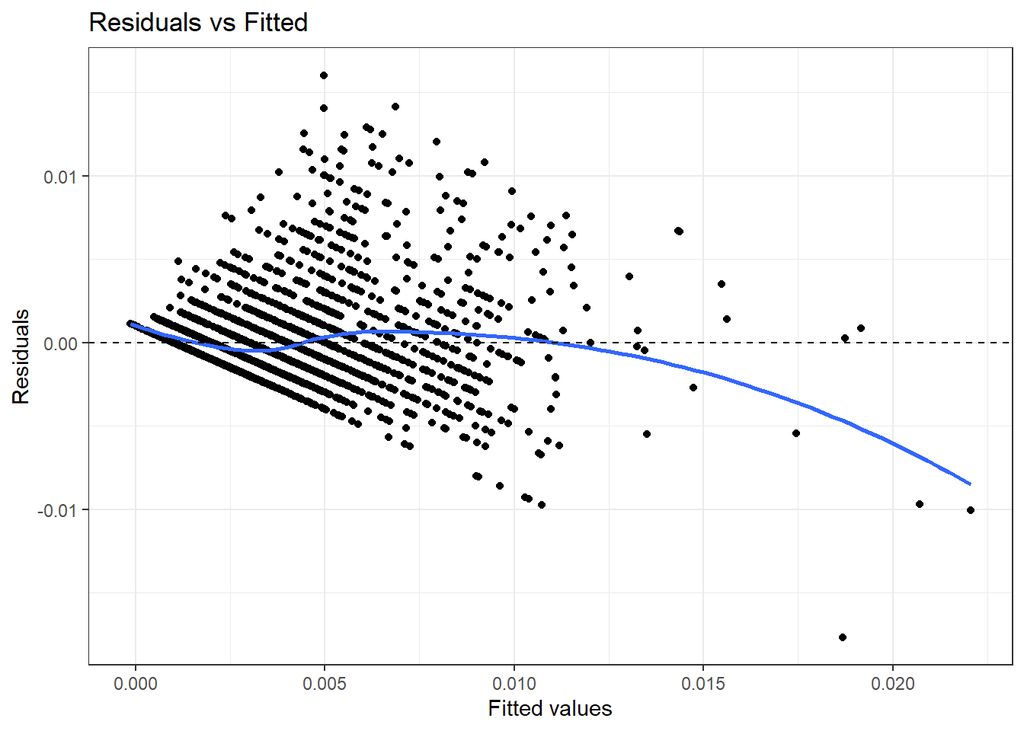

**Nhận xét**: Hình vẽ cho thấy xu hướng đường cong

=> Giả định về tuyến tính của mô hình là chưa phù hợp

##### Kiểm đinh đồng nhất phương sai

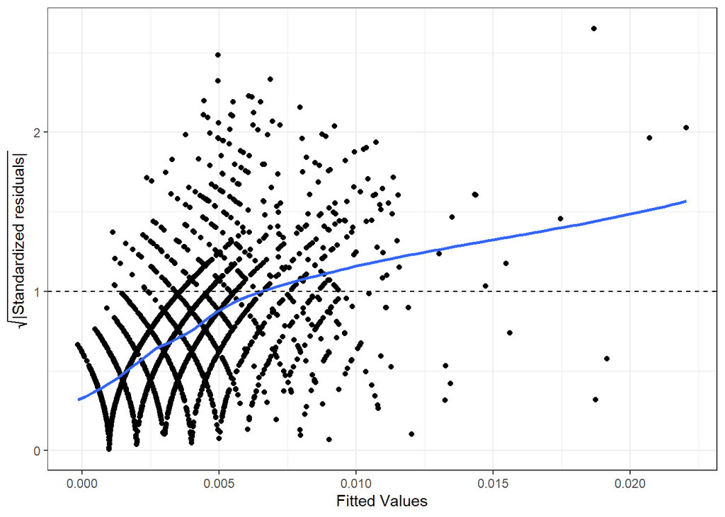

**Nhận xét**: Đồ thị không xấp xỉ đường thẳng 1

=> Giả định về phương sai đồng nhất là chưa hợp lý

##### Kiểm tra đa cộng tuyến

```r
vif(st_model_final)
```

```
##                      age                    value international_reputation
##                 1.970745                 3.406492                 1.123052
##                body_type                 crossing            short_passing
##                 1.069888                 2.445412                 2.466110
##                  volleys              fk_accuracy             sprint_speed
##                 2.165438                 1.825777                 1.299870
##               long_shots            interceptions                penalties
##                 1.961539                 1.597124                 1.451121
##                  marking           release_clause
##                 1.269708                 2.443145
```

**Nhận xét**: Mô hình không xảy ra đa cộng tuyến.

#### 3.2.6 Đánh giá mô hình

##### RMSE của mô hình

```r
set.seed(5)  # Để tái tạo kết quả

# Chia dữ liệu thành tập huấn luyện và kiểm tra (80% huấn luyện, 20% kiểm tra)
train_index <- sample(seq_len(nrow(df_st_numeric)), size = 0.8 * nrow(df_st_numeric))
train_data <- df_st_numeric[train_index, ]
test_data <- df_st_numeric[-train_index, ]

# Tạo công thức mô hình với các biến đã chọn
st_formula_final <- as.formula(paste("wage ~", paste(st_best_vars, collapse = "+")))

# Huấn luyện mô hình hồi quy tuyến tính
st_model_final <- lm(st_formula_final, data = train_data)

# Dự đoán trên tập kiểm tra
st_predictions <- predict(st_model_final, newdata = test_data)

# Tính toán RMSE trên tập kiểm tra
actual_values <- test_data$wage
rmse <- sqrt(mean((actual_values - st_predictions)^2))
print(paste("RMSE từ tập kiểm tra: ", rmse))
```

```
## [1] "RMSE từ tập kiểm tra:  0.00289245692314558"
```

#### R2 Score

```r
actual_values <- df_st_numeric$wage
predicted_values <- st_predict_wage
ss_res <- sum((actual_values - predicted_values)^2)
ss_tot <- sum((actual_values - mean(actual_values))^2)
r2 <- 1 - (ss_res / ss_tot)
print(paste("R2 Score của mô hình là:", r2))
```

```
## [1] "R2 Score của mô hình là: 0.46975409069995"
```

#### Áp dụng k-fold validation để tính RMSE

```r
# Áp dụng K-Fold CV với k = 5
k <- 5
k_fold_result <- k_fold_cv(df_st_numeric, st_formula_final, k)
```

```
## [1] "RMSE từ K-Fold CV (k = 5 ): 0.00248498625595289"
```

#### 3.2.7 Mở rộng mô hình

##### Khởi tạo mô hình

Ta sẽ tiến hành chạy mô hình bậc 2 với các biến có ít độ tuyến tính với mô hình

```r
coeffs <- summary(st_model_final)$coefficients

if (is.matrix(coeffs)) {
  p_values <- coeffs[, "Pr(>|t|)"]
} else {
  # Khi chỉ có một biến độc lập
  p_values <- coeffs["Pr(>|t|)"]
}

# Loại bỏ hệ số intercept (nếu cần)
p_values <- p_values[-1]  # Loại bỏ dòng đầu tiên (Intercept)

# Phân loại biến theo p-value
st_2 <- names(p_values[p_values > 0.05])  # Biến có p-value > 0.05
st_1 <- names(p_values[p_values <= 0.05]) # Biến có p-value <= 0.05

st_best_vars_1 <- st_best_vars[st_best_vars %in% st_1]
st_best_vars_2 <- st_best_vars[st_best_vars %in% st_2]
# Tạo công thức mô hình bậc hai
st_formula_final <- as.formula(paste(
  "wage ~",
  paste(st_best_vars_1, collapse = "+"),
  "+",
  paste(paste0("I(", st_best_vars_2, "^2)"), collapse = "+")
))

# Chạy mô hình hồi quy tuyến tính bậc hai với các biến đã chọn
st_model_final <- lm(st_formula_final, data = df_st_numeric)
```

```r
# In kết quả của mô hình
summary(st_model_final)
```

```
##
## Call:
## lm(formula = st_formula_final, data = df_st_numeric)
##
## Residuals:
##        Min         1Q     Median         3Q        Max
## -0.0176604 -0.0013666 -0.0003683  0.0006918  0.0160229
##
## Coefficients:
##                            Estimate Std. Error t value Pr(>|t|)
## (Intercept)              -2.738e-03  8.366e-04  -3.273 0.001080 **
## age                       9.238e-05  1.546e-05   5.976 2.62e-09 ***
## value                     1.516e-03  1.720e-04   8.815  < 2e-16 ***
## international_reputation  1.223e-03  3.696e-04   3.310 0.000946 ***
## crossing                  2.539e-05  6.476e-06   3.921 9.06e-05 ***
## short_passing            -2.613e-05  1.026e-05  -2.546 0.010949 *
## volleys                   1.761e-05  7.908e-06   2.227 0.026050 *
## fk_accuracy              -1.466e-05  5.747e-06  -2.550 0.010822 *
## sprint_speed             -2.054e-05  5.649e-06  -3.636 0.000282 ***
## long_shots                2.370e-05  9.408e-06   2.519 0.011837 *
## interceptions             1.591e-05  5.769e-06   2.759 0.005845 **
## penalties                 1.251e-05  7.578e-06   1.650 0.099015 .
## marking                  -1.292e-05  5.324e-06  -2.427 0.015286 *
## release_clause            1.008e-03  5.618e-05  17.937  < 2e-16 ***
## I(body_type^2)           -4.466e-06  2.328e-06  -1.919 0.055149 .
## ---
## Signif. codes:  0 '***' 0.001 '**' 0.01 '*' 0.05 '.' 0.1 ' ' 1
##
## Residual standard error: 0.002606 on 2507 degrees of freedom
## Multiple R-squared:  0.4698, Adjusted R-squared:  0.4668
## F-statistic: 158.7 on 14 and 2507 DF,  p-value: < 2.2e-16
```

##### Đường thẳng hồi quy

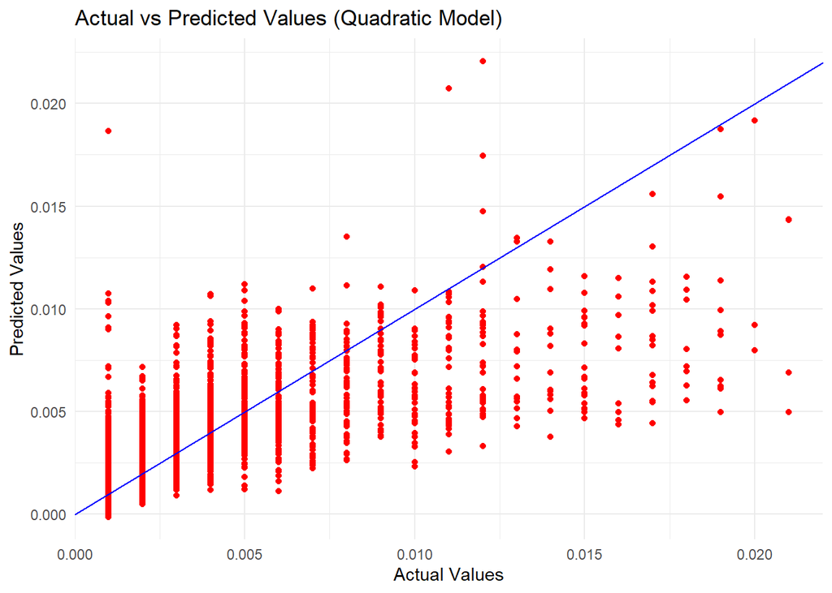

##### Đánh giá mô hình

```
## [1] "RMSE từ tập kiểm tra (Quadratic Model):  0.00283056447000361"
```

```
## [1] "R2 Score của mô hình bậc hai là: 0.469784531538054"
```

**Nhận xét**: Mô hình bậc 2 có kết quả chạy tốt hơn, với R2 Score cao hơn và RMSE thấp hơn.

### 3.3 Mô hình hồi quy dự đoán mức lương cho vị trí Tiền vệ

#### 3.3.1 Lựa chọn biến phù hợp cho mô hình

```r
df_mid_numeric <- df_mid_numeric |> select_if(is.numeric)

# Tìm các biến phụ thuộc tuyến tính
lin_combos <- findLinearCombos(df_mid_numeric)
# Loại bỏ các biến phụ thuộc tuyến tính (nếu có)
if (!is.null(lin_combos$remove)) {
  df_mid_cleaned <- df_mid_numeric[, -lin_combos$remove]
} else {
  df_mid_cleaned <- df_mid_numeric
}

# Loại bỏ các biến không có ý nghĩa
df_mid_numeric <- df_mid_cleaned |> select(-c(id, nationality, club))
```

Dùng Stepwise để lựa chọn các biến phù hợp:

```r
# Chạy stepwise để giảm số lượng biến
md_full <- lm(wage ~ ., data = df_mid_numeric)
step_md <- step(md_full, direction = "both")

# Lấy danh sách biến từ stepwise
selected_vars <- names(coef(step_md))[-1]
```

Các biến phù hợp để khởi tạo mô hình là:

```r
print(selected_vars)
```

```
##  [1] "age"                      "value"
##  [3] "preferred_foot"           "international_reputation"
##  [5] "body_type"                "crossing"
##  [7] "heading_accuracy"         "short_passing"
##  [9] "sprint_speed"             "shot_power"
## [11] "stamina"                  "long_shots"
## [13] "aggression"               "penalties"
## [15] "marking"                  "sliding_tackle"
## [17] "release_clause"
```

#### 3.3.2 Biểu đồ RMSE cho các biến đã chọn

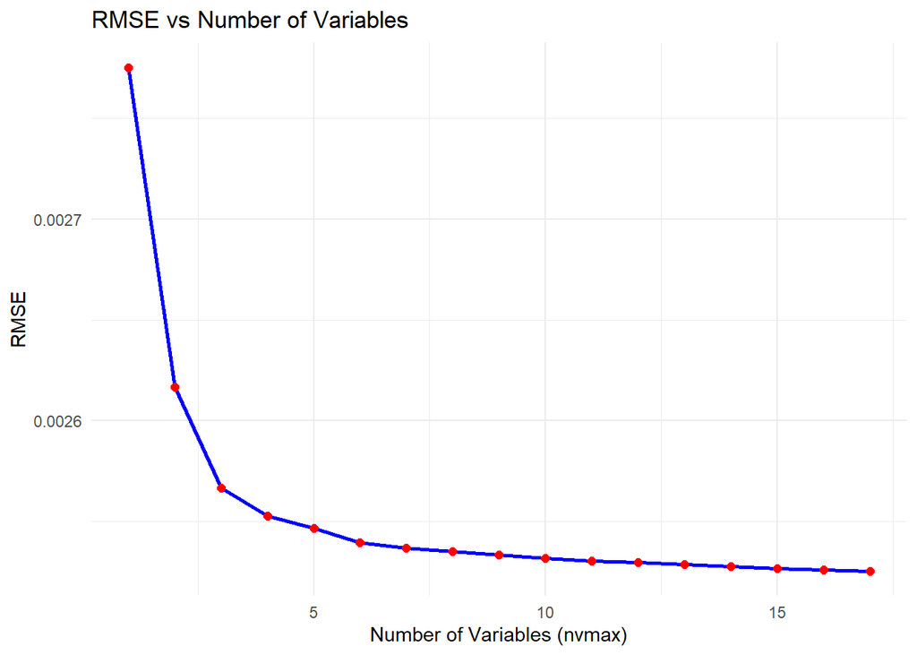

**Nhận xét**: Vậy, các biến trên được chọn để khởi tạo mô hình là phù hợp

#### 3.3.3 Áp dụng mô hình cho các biến đã chọn

```
##
## Call:
## lm(formula = mid_formula_final, data = df_mid_numeric)
##
## Residuals:
##        Min         1Q     Median         3Q        Max
## -0.0116559 -0.0013186 -0.0002897  0.0007316  0.0158252
##
## Coefficients:
##                            Estimate Std. Error t value Pr(>|t|)
## (Intercept)              -3.581e-03  7.018e-04  -5.103 3.46e-07 ***
## age                       1.474e-04  1.063e-05  13.867  < 2e-16 ***
## value                     1.642e-03  1.251e-04  13.130  < 2e-16 ***
## preferred_foot            1.931e-04  8.920e-05   2.165 0.030420 *
## international_reputation  1.543e-03  2.748e-04   5.614 2.08e-08 ***
## body_type                -5.860e-05  2.163e-05  -2.709 0.006772 **
## crossing                  1.242e-05  5.076e-06   2.447 0.014426 *
## heading_accuracy          1.589e-05  4.398e-06   3.613 0.000305 ***
## short_passing            -1.698e-05  8.509e-06  -1.995 0.046057 *
## sprint_speed             -1.100e-05  4.433e-06  -2.481 0.013123 *
## shot_power                9.192e-06  6.043e-06   1.521 0.128285
## stamina                  -1.679e-05  3.826e-06  -4.388 1.17e-05 ***
## long_shots               -1.046e-05  5.040e-06  -2.075 0.037991 *
## aggression                8.964e-06  3.914e-06   2.290 0.022042 *
## penalties                 1.545e-05  4.830e-06   3.199 0.001388 **
## marking                  -1.289e-05  3.960e-06  -3.256 0.001138 **
## sliding_tackle            8.936e-06  4.148e-06   2.154 0.031264 *
## release_clause            1.035e-03  4.511e-05  22.950  < 2e-16 ***
## ---
## Signif. codes:  0 '***' 0.001 '**' 0.01 '*' 0.05 '.' 0.1 ' ' 1
##
## Residual standard error: 0.00253 on 5002 degrees of freedom
## Multiple R-squared:  0.4692, Adjusted R-squared:  0.4674
## F-statistic: 260.1 on 17 and 5002 DF,  p-value: < 2.2e-16
```

**Nhận xét**:

#### 3.3.4 Biểu đồ hồi quy

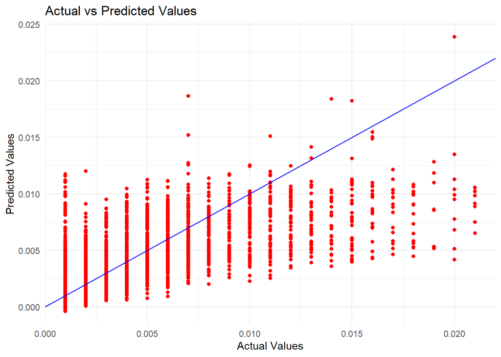

```r
# Dự đoán với mô hình mới
mid_predict_wage <- predict(mid_model_final, newdata = df_mid_numeric)

# Vẽ biểu đồ dự đoán so với giá trị thực tế
result <- data.frame(actual_values = df_mid_numeric$wage, predictions = mid_predict_wage)

ggplot(result, aes(x = actual_values, y = predictions)) +
  geom_point(color = "red") +
  geom_abline(slope = 1, intercept = 0, color = "blue") +
  labs(
    title = "Actual vs Predicted Values",
    x = "Actual Values",
    y = "Predicted Values"
  ) +
  theme_minimal()
```

**Nhận xét**: Đường thẳng hồi quy không quá khớp với dữ liệu.

#### 3.3.5 Một số chuẩn đoán cho mô hình

##### Kiểm định tuyến tính mô hình

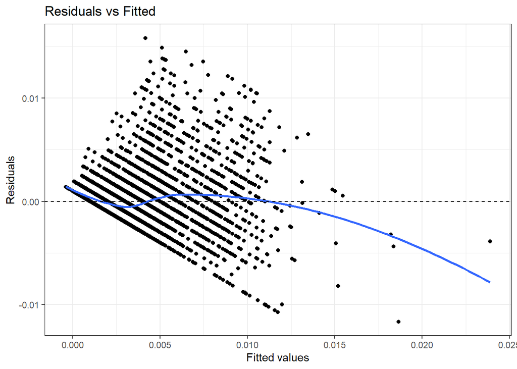

**Nhận xét**: Hình vẽ cho thấy xu hướng đường cong

=> Giả định về tuyến tính của mô hình là chưa phù hợp

##### Kiểm đinh đồng nhất phương sai

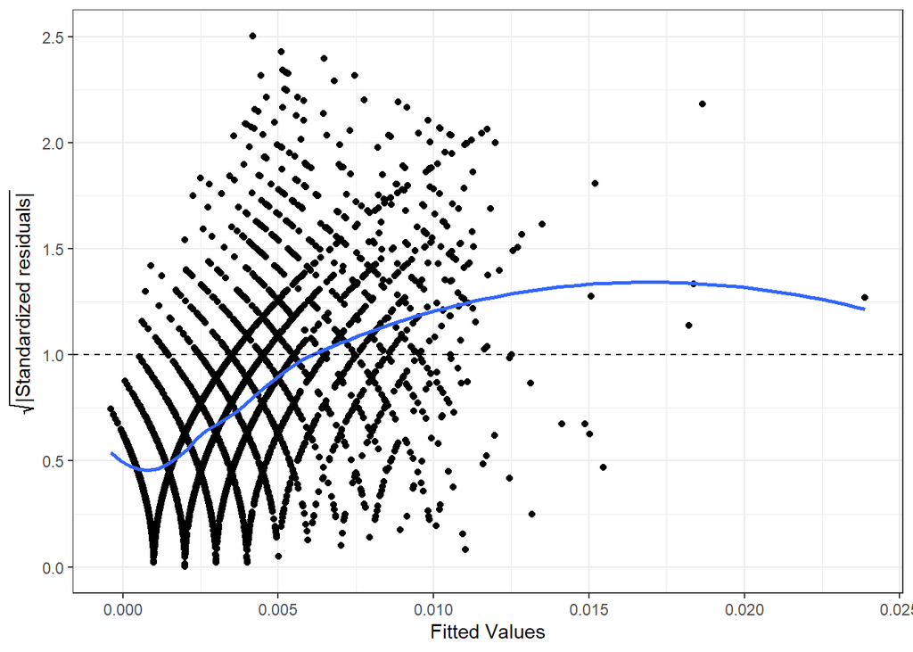

**Nhận xét**: Đồ thị không xấp xỉ đường thẳng 1

=> Giả định về phương sai đồng nhất là chưa hợp lý

##### Kiểm tra đa cộng tuyến

```r
vif(mid_model_final)
```

```
##                      age                    value           preferred_foot
##                 1.952036                 3.723928                 1.056622
## international_reputation                body_type                 crossing
##                 1.113882                 1.088238                 1.934375
##         heading_accuracy            short_passing             sprint_speed
##                 1.514960                 2.192926                 1.615083
##               shot_power                  stamina               long_shots
##                 2.363928                 1.619735                 2.580159
##               aggression                penalties                  marking
##                 2.359431                 1.721701                 2.474833
##           sliding_tackle           release_clause
##                 3.007448                 2.718878
```

**Nhận xét**: Mô hình không xảy ra đa cộng tuyến.

#### 3.3.6 Đánh giá mô hình

##### RMSE của mô hình

```r
# Đánh giá mô hình với tập kiểm tra
set.seed(5)  # Để tái tạo kết quả

# Chia dữ liệu thành tập huấn luyện và kiểm tra (80% huấn luyện, 20% kiểm tra)
train_index <- sample(seq_len(nrow(df_mid_numeric)), size = 0.8 * nrow(df_mid_numeric))
train_data <- df_mid_numeric[train_index, ]
test_data <- df_mid_numeric[-train_index, ]

# Tạo công thức mô hình với các biến đã chọn
mid_formula_final <- as.formula(paste("wage ~", paste(mid_best_vars, collapse = "+")))

# Huấn luyện mô hình hồi quy tuyến tính
mid_model_final <- lm(mid_formula_final, data = train_data)

# Dự đoán trên tập kiểm tra
mid_predictions <- predict(mid_model_final, newdata = test_data)

# Tính toán RMSE trên tập kiểm tra
actual_values <- test_data$wage
rmse <- sqrt(mean((actual_values - mid_predictions)^2))
print(paste("RMSE từ tập kiểm tra: ", rmse))
```

```
## [1] "RMSE từ tập kiểm tra:  0.00243507815155239"
```

##### R2 Score

```r
actual_values <- df_mid_numeric$wage
predicted_values <- mid_predict_wage
ss_res <- sum((actual_values - predicted_values)^2)
ss_tot <- sum((actual_values - mean(actual_values))^2)
r2 <- 1 - (ss_res / ss_tot)
print(paste("R2 Score của mô hình là:", r2))
```

```
## [1] "R2 Score của mô hình là: 0.469163237053813"
```

##### Áp dụng k-fold validation để tính RMSE

```r
# Áp dụng K-Fold CV với k = 5
k <- 5
k_fold_result <- k_fold_cv(df_mid_numeric, mid_formula_final, k)
```

```
## [1] "RMSE từ K-Fold CV (k = 5 ): 0.00241815308946973"
```

#### 3.3.7 Mở rộng mô hình

##### Khởi tạo mô hình

Ta sẽ tiến hành chạy mô hình bậc 2 với các biến có ít độ tuyến tính với mô hình

```r
coeffs <- summary(mid_model_final)$coefficients

if (is.matrix(coeffs)) {
  p_values <- coeffs[, "Pr(>|t|)"]
} else {
  # Khi chỉ có một biến độc lập
  p_values <- coeffs["Pr(>|t|)"]
}

# Loại bỏ hệ số intercept (nếu cần)
p_values <- p_values[-1]  # Loại bỏ dòng đầu tiên (Intercept)

# Phân loại biến theo p-value
mid_2 <- names(p_values[p_values > 0.05])  # Biến có p-value > 0.05
mid_1 <- names(p_values[p_values <= 0.05]) # Biến có p-value <= 0.05

mid_best_vars_1 <- mid_best_vars[mid_best_vars %in% mid_1]
mid_best_vars_2 <- mid_best_vars[mid_best_vars %in% mid_2]

# Tạo công thức mô hình bậc hai với các biến đã chọn
mid_formula_final <- as.formula(paste(
  "wage ~",
  paste(mid_best_vars_1, collapse = "+"),
  "+",
  paste(paste0("I(", mid_best_vars_2, "^2)"), collapse = "+")
))

# Chạy mô hình hồi quy bậc hai với các biến đã chọn
mid_model_final <- lm(mid_formula_final, data = df_mid_numeric)
```

```r
# In kết quả của mô hình
summary(mid_model_final)
```

```
##
## Call:
## lm(formula = mid_formula_final, data = df_mid_numeric)
##
## Residuals:
##        Min         1Q     Median         3Q        Max
## -0.0116727 -0.0013166 -0.0002936  0.0007268  0.0158793
##
## Coefficients:
##                            Estimate Std. Error t value Pr(>|t|)
## (Intercept)              -3.022e-03  7.097e-04  -4.259 2.09e-05 ***
## age                       1.471e-04  1.058e-05  13.899  < 2e-16 ***
## value                     1.626e-03  1.250e-04  13.008  < 2e-16 ***
## preferred_foot            1.963e-04  8.916e-05   2.202  0.02771 *
## international_reputation  1.518e-03  2.749e-04   5.522 3.53e-08 ***
## body_type                -5.929e-05  2.162e-05  -2.743  0.00611 **
## crossing                  1.244e-05  5.071e-06   2.452  0.01422 *
## heading_accuracy          1.454e-05  4.419e-06   3.290  0.00101 **
## short_passing            -1.752e-05  8.437e-06  -2.077  0.03786 *
## sprint_speed             -1.042e-05  4.425e-06  -2.355  0.01856 *
## stamina                  -1.697e-05  3.826e-06  -4.436 9.36e-06 ***
## long_shots               -1.100e-05  5.034e-06  -2.184  0.02900 *
## aggression                7.532e-06  3.899e-06   1.932  0.05345 .
## penalties                 1.532e-05  4.820e-06   3.178  0.00149 **
## marking                  -1.476e-05  3.979e-06  -3.710  0.00021 ***
## release_clause            1.035e-03  4.508e-05  22.953  < 2e-16 ***
## I(shot_power^2)           1.036e-07  5.109e-08   2.029  0.04255 *
## I(sliding_tackle^2)       1.476e-07  4.762e-08   3.100  0.00195 **
## ---
## Signif. codes:  0 '***' 0.001 '**' 0.01 '*' 0.05 '.' 0.1 ' ' 1
##
## Residual standard error: 0.002528 on 5002 degrees of freedom
## Multiple R-squared:  0.4699, Adjusted R-squared:  0.4681
## F-statistic: 260.8 on 17 and 5002 DF,  p-value: < 2.2e-16
```

##### Đường thẳng hồi quy

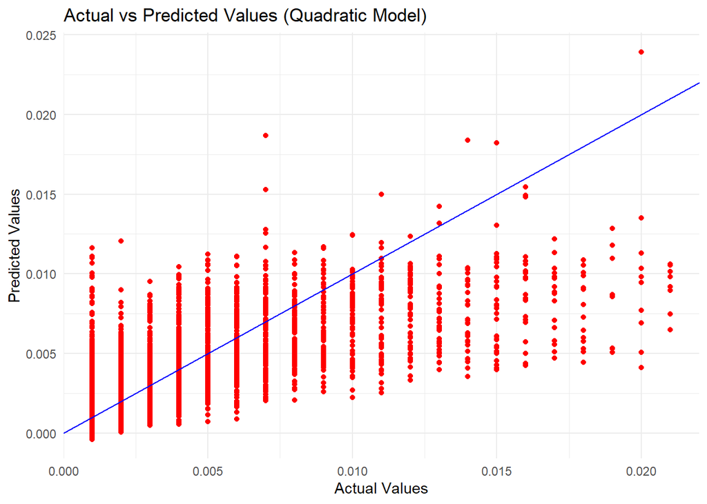

##### Đánh giá mô hình

```
## [1] "RMSE từ tập kiểm tra (Quadratic Model):  0.00244007195905395"
```

```
## [1] "R2 Score của mô hình bậc hai là: 0.469876342612879"
```

**Nhận xét**: Mô hình bậc 2 có kết quả chạy tương đương.

### 3.4 Mô hình hồi quy dự đoán mức lương cho vị trí Hậu vệ

#### 3.4.1 Lựa chọn biến phù hợp cho mô hình

```r
df_defender_numeric <- df_df_numeric |> select_if(is.numeric)

# Tìm các biến phụ thuộc tuyến tính
lin_combos <- findLinearCombos(df_defender_numeric)
# Loại bỏ các biến phụ thuộc tuyến tính (nếu có)
if (!is.null(lin_combos$remove)) {
  df_defender_cleaned <- df_defender_numeric[, -lin_combos$remove]
} else {
  df_defender_cleaned <- df_defender_numeric
}

# Loại bỏ các biến không có ý nghĩa
df_defender_numeric <- df_defender_cleaned |> select(-c(id, nationality, club))
```

Dùng Stepwise để lựa chọn các biến phù hợp:

```r
# Chạy stepwise để giảm số lượng biến
md_full <- lm(wage ~ ., data = df_defender_numeric)
step_md <- step(md_full, direction = "both")

# Lấy danh sách biến từ stepwise
selected_vars <- names(coef(step_md))[-1]
```

Các biến phù hợp để khởi tạo mô hình là:

```r
print(selected_vars)
```

```
##  [1] "age"                      "potential"
##  [3] "value"                    "international_reputation"
##  [5] "skill_moves"              "body_type"
##  [7] "crossing"                 "heading_accuracy"
##  [9] "curve"                    "shot_power"
## [11] "stamina"                  "long_shots"
## [13] "interceptions"            "penalties"
## [15] "sliding_tackle"           "release_clause"
```

#### 3.4.2 Biểu đồ RMSE cho các biến đã chọn

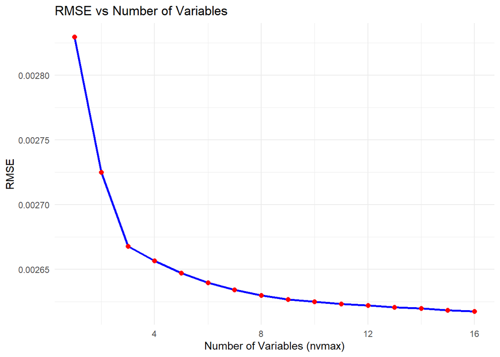

**Nhận xét**: Vậy, các biến trên được chọn để khởi tạo mô hình là phù hợp

#### 3.4.3 Áp dụng mô hình cho các biến đã chọn

```
##
## Call:
## lm(formula = defender_formula_final, data = df_defender_numeric)
##
## Residuals:
##       Min        1Q    Median        3Q       Max
## -0.012566 -0.001392 -0.000366  0.000833  0.015611
##
## Coefficients:
##                            Estimate Std. Error t value Pr(>|t|)
## (Intercept)              -8.267e-03  1.096e-03  -7.540 5.62e-14 ***
## age                       1.653e-04  1.568e-05  10.544  < 2e-16 ***
## potential                 3.246e-05  1.436e-05   2.260 0.023853 *
## value                     1.981e-03  1.579e-04  12.550  < 2e-16 ***
## international_reputation  1.031e-03  2.744e-04   3.756 0.000175 ***
## skill_moves               4.562e-04  1.301e-04   3.506 0.000459 ***
## body_type                -5.624e-05  2.345e-05  -2.398 0.016520 *
## crossing                  6.901e-06  4.075e-06   1.693 0.090450 .
## heading_accuracy          1.680e-05  6.124e-06   2.743 0.006103 **
## curve                     8.650e-06  4.653e-06   1.859 0.063119 .
## shot_power               -1.164e-05  4.638e-06  -2.510 0.012107 *
## stamina                  -2.425e-05  4.454e-06  -5.444 5.49e-08 ***
## long_shots                1.009e-05  4.940e-06   2.043 0.041140 *
## interceptions            -2.363e-05  9.349e-06  -2.528 0.011503 *
## penalties                 1.325e-05  4.967e-06   2.668 0.007668 **
## sliding_tackle            4.246e-05  9.951e-06   4.267 2.03e-05 ***
## release_clause            7.541e-04  5.933e-05  12.711  < 2e-16 ***
## ---
## Signif. codes:  0 '***' 0.001 '**' 0.01 '*' 0.05 '.' 0.1 ' ' 1
##
## Residual standard error: 0.002622 on 4572 degrees of freedom
## Multiple R-squared:  0.4517, Adjusted R-squared:  0.4497
## F-statistic: 235.4 on 16 and 4572 DF,  p-value: < 2.2e-16
```

**Nhận xét**: